# Install libraries

```python
import os
import pandas as pd
import numpy as np
import matplotlib
import pandas_profiling as pf

from io import BytesIO
from pandas.io import sql
from sqlalchemy import create_engine
from mysql import connector
from google.cloud import storage
from google.cloud import bigquery

%matplotlib inline
import matplotlib.pyplot as plt
#plt.switch_backend('agg')

pd.set_option('display.max_columns', None)
```

# Configure connection with Cloud SQL

```python
user='ea-developer'
host='35.205.32.16'
port='3306'
db='ea_datalake'
database_connection = create_engine('mysql+mysqlconnector://{0}:@{1}:{2}/{3}'.format(user, host, port, db))
```

# Configure connection with Bigquery

```python
bigquery_client = bigquery.Client()
```

Create a new dataset associated to the project

```python
dataset_id = 'shining-bearing-255613.ea'
dataset = bigquery.Dataset(dataset_id)
dataset.location = "EU"
dataset = bigquery_client.create_dataset(dataset)
```

# Configure connection with Cloud Storage

```python
# Instantiates a client
storage_client = storage.Client()

# The name for the new bucket
bucket_name = 'ea-datalake-dev'
```

```python
def upload_blob(bucket_name, source_file_name, destination_blob_name):
    """Uploads a file to the bucket."""
    storage_client = storage.Client()
    bucket = storage_client.get_bucket(bucket_name)
    blob = bucket.blob(destination_blob_name)

    blob.upload_from_filename(source_file_name)

    print('File {} uploaded to {}.'.format(
        source_file_name,
        destination_blob_name))

def list_blobs(bucket_name):
    """Lists all the blobs in the bucket."""
    storage_client = storage.Client()
    bucket = storage_client.get_bucket(bucket_name)

    blobs = bucket.list_blobs()

    for blob in blobs:
        print(blob.name)
```

# Data Quality

Extract data aobut FIFA 18 players, previously loaded into our Cloud SQL database

```python
df_players = pd.read_sql('SELECT * FROM ea_complete_dataset', con=database_connection)
```

View some descriptive information about our dataframe

```python
print(df_players.shape)
```

```
(17981, 74)
```

```python
print(df_players.columns)
```

```
Index(['Name', 'Age', 'Photo', 'Nationality', 'Flag', 'Overall', 'Potential',
       'Club', 'Club Logo', 'Value', 'Wage', 'Special', 'Acceleration',
       'Aggression', 'Agility', 'Balance', 'Ball control', 'Composure',
       'Crossing', 'Curve', 'Dribbling', 'Finishing', 'Free kick accuracy',
       'GK diving', 'GK handling', 'GK kicking', 'GK positioning',
       'GK reflexes', 'Heading accuracy', 'Interceptions', 'Jumping',
       'Long passing', 'Long shots', 'Marking', 'Penalties', 'Positioning',
       'Reactions', 'Short passing', 'Shot power', 'Sliding tackle',
       'Sprint speed', 'Stamina', 'Standing tackle', 'Strength', 'Vision',
       'Volleys', 'CAM', 'CB', 'CDM', 'CF', 'CM', 'ID', 'LAM', 'LB', 'LCB',
       'LCM', 'LDM', 'LF', 'LM', 'LS', 'LW', 'LWB', 'Preferred Positions',
       'RAM', 'RB', 'RCB', 'RCM', 'RDM', 'RF', 'RM', 'RS', 'RW', 'RWB', 'ST'],
      dtype='object')
```

```python
df_players.head()
```

|  | Name | Age | Photo | Nationality | Flag | Overall | Potential | Club | Club Logo | Value | Wage | Special | Acceleration | Aggression | Agility | Balance | Ball control | Composure | Crossing | Curve | Dribbling | Finishing | Free kick accuracy | GK diving | GK handling | GK kicking | GK positioning | GK reflexes | Heading accuracy | … |
| --- | --- | --- | --- | --- | --- | --- | --- | --- | --- | --- | --- | --- | --- | --- | --- | --- | --- | --- | --- | --- | --- | --- | --- | --- | --- | --- | --- | --- | --- | --- |
| 0 | Cristiano Ronaldo | 32 | https://cdn.sofifa.org/48/18/players/20801.png | Portugal | https://cdn.sofifa.org/flags/38.png | 94 | 94 | Real Madrid CF | https://cdn.sofifa.org/24/18/teams/243.png | €95.5M | €565K | 2228 | 89 | 63 | 89 | 63 | 93 | 95 | 85 | 81 | 91 | 94 | 76 | 7 | 11 | 15 | 14 | 11 | 88 | … |
| 1 | L. Messi | 30 | https://cdn.sofifa.org/48/18/players/158023.png | Argentina | https://cdn.sofifa.org/flags/52.png | 93 | 93 | FC Barcelona | https://cdn.sofifa.org/24/18/teams/241.png | €105M | €565K | 2154 | 92 | 48 | 90 | 95 | 95 | 96 | 77 | 89 | 97 | 95 | 90 | 6 | 11 | 15 | 14 | 8 | 71 | … |
| 2 | Neymar | 25 | https://cdn.sofifa.org/48/18/players/190871.png | Brazil | https://cdn.sofifa.org/flags/54.png | 92 | 94 | Paris Saint-Germain | https://cdn.sofifa.org/24/18/teams/73.png | €123M | €280K | 2100 | 94 | 56 | 96 | 82 | 95 | 92 | 75 | 81 | 96 | 89 | 84 | 9 | 9 | 15 | 15 | 11 | 62 | … |
| 3 | L. Suárez | 30 | https://cdn.sofifa.org/48/18/players/176580.png | Uruguay | https://cdn.sofifa.org/flags/60.png | 92 | 92 | FC Barcelona | https://cdn.sofifa.org/24/18/teams/241.png | €97M | €510K | 2291 | 88 | 78 | 86 | 60 | 91 | 83 | 77 | 86 | 86 | 94 | 84 | 27 | 25 | 31 | 33 | 37 | 77 | … |
| 4 | M. Neuer | 31 | https://cdn.sofifa.org/48/18/players/167495.png | Germany | https://cdn.sofifa.org/flags/21.png | 92 | 92 | FC Bayern Munich | https://cdn.sofifa.org/24/18/teams/21.png | €61M | €230K | 1493 | 58 | 29 | 52 | 35 | 48 | 70 | 15 | 14 | 30 | 13 | 11 | 91 | 90 | 95 | 91 | 89 | 25 | … |

```python
df_players.describe()
```

|  | Age | Overall | Potential | Special | CAM | CB | CDM | CF | CM | ID | LAM | LB | LCB | LCM | LDM | LF | LM | LS | LW | LWB | RAM | RB | RCB | RCM | RDM | RF | RM | RS | RW | … |
| --- | --- | --- | --- | --- | --- | --- | --- | --- | --- | --- | --- | --- | --- | --- | --- | --- | --- | --- | --- | --- | --- | --- | --- | --- | --- | --- | --- | --- | --- | --- |
| count | 17981.000000 | 17981.000000 | 17981.000000 | 17981.000000 | 15952.000000 | 15952.000000 | 15952.000000 | 15952.000000 | 15952.000000 | 17981.000000 | 15952.000000 | 15952.000000 | 15952.000000 | 15952.000000 | 15952.000000 | 15952.000000 | 15952.000000 | 15952.000000 | 15952.000000 | 15952.000000 | 15952.000000 | 15952.000000 | 15952.000000 | 15952.000000 | 15952.000000 | 15952.000000 | 15952.000000 | 15952.000000 | 15952.000000 | … |
| mean | 25.144541 | 66.247984 | 71.190813 | 1594.095100 | 59.251755 | 55.550464 | 56.865283 | 59.030028 | 58.506833 | 207658.710138 | 59.251755 | 56.979689 | 55.550464 | 58.506833 | 56.865283 | 59.030028 | 60.057736 | 58.204050 | 59.359265 | 57.698721 | 59.251755 | 56.979689 | 55.550464 | 58.506833 | 56.865283 | 59.030028 | 60.057736 | 58.204050 | 59.359265 | … |
| std | 4.614272 | 6.987965 | 6.102199 | 272.151435 | 9.880164 | 12.192579 | 10.310178 | 9.926988 | 8.888040 | 32291.667313 | 9.880164 | 9.791627 | 12.192579 | 8.888040 | 10.310178 | 9.926988 | 9.349180 | 9.181392 | 9.978084 | 9.142825 | 9.880164 | 9.791627 | 12.192579 | 8.888040 | 10.310178 | 9.926988 | 9.349180 | 9.181392 | 9.978084 | … |
| min | 16.000000 | 46.000000 | 46.000000 | 728.000000 | 27.000000 | 25.000000 | 26.000000 | 27.000000 | 30.000000 | 16.000000 | 27.000000 | 30.000000 | 25.000000 | 30.000000 | 26.000000 | 27.000000 | 28.000000 | 31.000000 | 26.000000 | 31.000000 | 27.000000 | 30.000000 | 25.000000 | 30.000000 | 26.000000 | 27.000000 | 28.000000 | 31.000000 | 26.000000 | … |
| 25% | 21.000000 | 62.000000 | 67.000000 | 1449.000000 | 53.000000 | 45.000000 | 49.000000 | 53.000000 | 53.000000 | 192622.000000 | 53.000000 | 50.000000 | 45.000000 | 53.000000 | 49.000000 | 53.000000 | 54.000000 | 52.000000 | 53.000000 | 51.000000 | 53.000000 | 50.000000 | 45.000000 | 53.000000 | 49.000000 | 53.000000 | 54.000000 | 52.000000 | 53.000000 | … |
| 50% | 25.000000 | 66.000000 | 71.000000 | 1633.000000 | 60.000000 | 57.000000 | 58.000000 | 60.000000 | 59.000000 | 214057.000000 | 60.000000 | 58.000000 | 57.000000 | 59.000000 | 58.000000 | 60.000000 | 61.000000 | 59.000000 | 60.000000 | 58.000000 | 60.000000 | 58.000000 | 57.000000 | 59.000000 | 58.000000 | 60.000000 | 61.000000 | 59.000000 | 60.000000 | … |
| 75% | 28.000000 | 71.000000 | 75.000000 | 1786.000000 | 66.000000 | 65.000000 | 65.000000 | 66.000000 | 65.000000 | 231448.000000 | 66.000000 | 64.000000 | 65.000000 | 65.000000 | 65.000000 | 66.000000 | 67.000000 | 65.000000 | 66.000000 | 64.000000 | 66.000000 | 64.000000 | 65.000000 | 65.000000 | 65.000000 | 66.000000 | 67.000000 | 65.000000 | 66.000000 | … |
| max | 47.000000 | 94.000000 | 94.000000 | 2291.000000 | 92.000000 | 87.000000 | 85.000000 | 92.000000 | 87.000000 | 241219.000000 | 92.000000 | 84.000000 | 87.000000 | 87.000000 | 85.000000 | 92.000000 | 90.000000 | 92.000000 | 91.000000 | 84.000000 | 92.000000 | 84.000000 | 87.000000 | 87.000000 | 85.000000 | 92.000000 | 90.000000 | 92.000000 | 91.000000 | … |

### Summary table with detailed information about each field/column

- Data type
- Count of missing values
- Count of present values
- Number of unique values
- Minimum value
- Maximum value
- Mean value
- Median value

```python
df_summary_dicc  = pd.DataFrame(columns=list(df_players.keys())).transpose()
df_summary_types = pd.DataFrame(df_players.dtypes).rename(columns = {0:'dtypes'})
df_summary_count = pd.DataFrame(df_players.count()).rename(columns = {0:'present_values'})
df_summary_nulls = pd.DataFrame(df_players.isnull().sum()).rename(columns = {0:'null_values'})
df_summary_unique= pd.DataFrame(df_players.nunique()).rename(columns = {0:'unique_values'})
df_summary_min   = pd.DataFrame(df_players.min()).rename(columns = {0:'min_value'})
df_summary_max   = pd.DataFrame(df_players.max()).rename(columns = {0:'max_value'})
df_summary_mean  = pd.DataFrame(df_players.mean()).rename(columns = {0:'mean_value'})
df_summary_median= pd.DataFrame(df_players.median()).rename(columns = {0:'median_value'})
df_summary = df_summary_dicc.join(df_summary_types).join(df_summary_count).join(df_summary_nulls)
df_summary['total_values'] = df_summary['present_values'] + df_summary['null_values']
df_summary = df_summary.join(df_summary_unique).join(df_summary_min).join(df_summary_max)
df_summary = df_summary.join(df_summary_mean).join(df_summary_median)
df_summary
```

|  | dtypes | present_values | null_values | total_values | unique_values | min_value | max_value | mean_value | median_value |
| --- | --- | --- | --- | --- | --- | --- | --- | --- | --- |
| Name | object | 17981 | 0 | 17981 | 16975 | A. Abbas | Óscar Whalley | NaN | NaN |
| Age | int64 | 17981 | 0 | 17981 | 29 | 16 | 47 | 25.144541 | 25.0 |
| Photo | object | 17981 | 0 | 17981 | 17929 | https://cdn.sofifa.org/48/18/players/101317.png | https://cdn.sofifa.org/48/18/players/9833.png | NaN | NaN |
| Nationality | object | 17981 | 0 | 17981 | 165 | Afghanistan | Zimbabwe | NaN | NaN |
| Flag | object | 17981 | 0 | 17981 | 165 | https://cdn.sofifa.org/flags/1.png | https://cdn.sofifa.org/flags/99.png | NaN | NaN |
| Overall | int64 | 17981 | 0 | 17981 | 49 | 46 | 94 | 66.247984 | 66.0 |
| Potential | int64 | 17981 | 0 | 17981 | 48 | 46 | 94 | 71.190813 | 71.0 |
| Club | object | 17733 | 248 | 17981 | 647 | NaN | NaN | NaN | NaN |
| Club Logo | object | 17981 | 0 | 17981 | 679 | https://cdn.sofifa.org/24/18/teams/1.png | https://cdn.sofifa.org/flags/9.png | NaN | NaN |
| Value | object | 17981 | 0 | 17981 | 207 | €0 | €9M | NaN | NaN |
| Wage | object | 17981 | 0 | 17981 | 142 | €0 | €9K | NaN | NaN |
| Special | int64 | 17981 | 0 | 17981 | 1396 | 728 | 2291 | 1594.095100 | 1633.0 |
| Acceleration | object | 17981 | 0 | 17981 | 161 | 11 | 96 | NaN | NaN |
| Aggression | object | 17981 | 0 | 17981 | 151 | 11 | 96 | NaN | NaN |
| Agility | object | 17981 | 0 | 17981 | 146 | 14 | 96 | NaN | NaN |
| Balance | object | 17981 | 0 | 17981 | 135 | 11 | 96 | NaN | NaN |
| Ball control | object | 17981 | 0 | 17981 | 184 | 10 | 95 | NaN | NaN |
| Composure | object | 17981 | 0 | 17981 | 161 | 11 | 96 | NaN | NaN |
| Crossing | object | 17981 | 0 | 17981 | 176 | 10 | 91 | NaN | NaN |
| Curve | object | 17981 | 0 | 17981 | 153 | 10 | 92 | NaN | NaN |
| Dribbling | object | 17981 | 0 | 17981 | 194 | 10 | 97 | NaN | NaN |
| Finishing | object | 17981 | 0 | 17981 | 187 | 10 | 95 | NaN | NaN |
| Free kick accuracy | object | 17981 | 0 | 17981 | 136 | 10 | 93 | NaN | NaN |
| GK diving | object | 17981 | 0 | 17981 | 100 | 1 | 91 | NaN | NaN |
| GK handling | object | 17981 | 0 | 17981 | 97 | 1 | 91 | NaN | NaN |
| GK kicking | object | 17981 | 0 | 17981 | 103 | 1 | 95 | NaN | NaN |
| GK positioning | object | 17981 | 0 | 17981 | 99 | 1 | 91 | NaN | NaN |
| GK reflexes | object | 17981 | 0 | 17981 | 102 | 1 | 90 | NaN | NaN |
| Heading accuracy | object | 17981 | 0 | 17981 | 158 | 10 | 94 | NaN | NaN |
| Interceptions | object | 17981 | 0 | 17981 | 174 | 10 | 92 | NaN | NaN |
| ... | ... | ... | ... | ... | ... | ... | ... | ... | ... |
| Vision | object | 17981 | 0 | 17981 | 173 | 10 | 94 | NaN | NaN |
| Volleys | object | 17981 | 0 | 17981 | 125 | 10 | 91 | NaN | NaN |
| CAM | float64 | 15952 | 2029 | 17981 | 64 | 27 | 92 | 59.251755 | 60.0 |
| CB | float64 | 15952 | 2029 | 17981 | 62 | 25 | 87 | 55.550464 | 57.0 |
| CDM | float64 | 15952 | 2029 | 17981 | 59 | 26 | 85 | 56.865283 | 58.0 |
| CF | float64 | 15952 | 2029 | 17981 | 64 | 27 | 92 | 59.030028 | 60.0 |
| CM | float64 | 15952 | 2029 | 17981 | 58 | 30 | 87 | 58.506833 | 59.0 |
| ID | int64 | 17981 | 0 | 17981 | 17929 | 16 | 241219 | 207658.710138 | 214057.0 |
| LAM | float64 | 15952 | 2029 | 17981 | 64 | 27 | 92 | 59.251755 | 60.0 |
| LB | float64 | 15952 | 2029 | 17981 | 55 | 30 | 84 | 56.979689 | 58.0 |
| LCB | float64 | 15952 | 2029 | 17981 | 62 | 25 | 87 | 55.550464 | 57.0 |
| LCM | float64 | 15952 | 2029 | 17981 | 58 | 30 | 87 | 58.506833 | 59.0 |
| LDM | float64 | 15952 | 2029 | 17981 | 59 | 26 | 85 | 56.865283 | 58.0 |
| LF | float64 | 15952 | 2029 | 17981 | 64 | 27 | 92 | 59.030028 | 60.0 |
| LM | float64 | 15952 | 2029 | 17981 | 61 | 28 | 90 | 60.057736 | 61.0 |
| LS | float64 | 15952 | 2029 | 17981 | 59 | 31 | 92 | 58.204050 | 59.0 |
| LW | float64 | 15952 | 2029 | 17981 | 64 | 26 | 91 | 59.359265 | 60.0 |
| LWB | float64 | 15952 | 2029 | 17981 | 54 | 31 | 84 | 57.698721 | 58.0 |
| Preferred Positions | object | 17981 | 0 | 17981 | 802 | CAM | ST RW RM | NaN | NaN |
| RAM | float64 | 15952 | 2029 | 17981 | 64 | 27 | 92 | 59.251755 | 60.0 |
| RB | float64 | 15952 | 2029 | 17981 | 55 | 30 | 84 | 56.979689 | 58.0 |
| RCB | float64 | 15952 | 2029 | 17981 | 62 | 25 | 87 | 55.550464 | 57.0 |
| RCM | float64 | 15952 | 2029 | 17981 | 58 | 30 | 87 | 58.506833 | 59.0 |
| RDM | float64 | 15952 | 2029 | 17981 | 59 | 26 | 85 | 56.865283 | 58.0 |
| RF | float64 | 15952 | 2029 | 17981 | 64 | 27 | 92 | 59.030028 | 60.0 |
| RM | float64 | 15952 | 2029 | 17981 | 61 | 28 | 90 | 60.057736 | 61.0 |
| RS | float64 | 15952 | 2029 | 17981 | 59 | 31 | 92 | 58.204050 | 59.0 |
| RW | float64 | 15952 | 2029 | 17981 | 64 | 26 | 91 | 59.359265 | 60.0 |
| RWB | float64 | 15952 | 2029 | 17981 | 54 | 31 | 84 | 57.698721 | 58.0 |
| ST | float64 | 15952 | 2029 | 17981 | 59 | 31 | 92 | 58.204050 | 59.0 |

74 rows × 9 columns

### Missing values

Registers with some fields without information

```python
df_players[df_players.isnull().any(axis=1)]
```

|  | Name | Age | Photo | Nationality | Flag | Overall | Potential | Club | Club Logo | Value | Wage | Special | Acceleration | Aggression | Agility | Balance | Ball control | Composure | Crossing | Curve | Dribbling | Finishing | Free kick accuracy | GK diving | GK handling | GK kicking | GK positioning | GK reflexes | Heading accuracy | … |
| --- | --- | --- | --- | --- | --- | --- | --- | --- | --- | --- | --- | --- | --- | --- | --- | --- | --- | --- | --- | --- | --- | --- | --- | --- | --- | --- | --- | --- | --- | --- |
| 4 | M. Neuer | 31 | https://cdn.sofifa.org/48/18/players/167495.png | Germany | https://cdn.sofifa.org/flags/21.png | 92 | 92 | FC Bayern Munich | https://cdn.sofifa.org/24/18/teams/21.png | €61M | €230K | 1493 | 58 | 29 | 52 | 35 | 48 | 70 | 15 | 14 | 30 | 13 | 11 | 91 | 90 | 95 | 91 | 89 | 25 | … |
| 6 | De Gea | 26 | https://cdn.sofifa.org/48/18/players/193080.png | Spain | https://cdn.sofifa.org/flags/45.png | 90 | 92 | Manchester United | https://cdn.sofifa.org/24/18/teams/11.png | €64.5M | €215K | 1458 | 57 | 38 | 60 | 43 | 42 | 64 | 17 | 21 | 18 | 13 | 19 | 90 | 85 | 87 | 86 | 90 | 21 | … |
| 12 | T. Courtois | 25 | https://cdn.sofifa.org/48/18/players/192119.png | Belgium | https://cdn.sofifa.org/flags/7.png | 89 | 92 | Chelsea | https://cdn.sofifa.org/24/18/teams/5.png | €59M | €190K | 1282 | 46 | 23 | 61 | 45 | 23 | 52 | 14 | 19 | 13 | 14 | 11 | 85 | 91 | 69 | 86 | 88 | 13 | … |
| 18 | G. Buffon | 39 | https://cdn.sofifa.org/48/18/players/1179.png | Italy | https://cdn.sofifa.org/flags/27.png | 89 | 89 | Juventus | https://cdn.sofifa.org/24/18/teams/45.png | €4.5M | €110K | 1335 | 49 | 38 | 55 | 49 | 28 | 70 | 13 | 20 | 26 | 15 | 13 | 89 | 88 | 74 | 90 | 84 | 13 | … |
| 20 | J. Oblak | 24 | https://cdn.sofifa.org/48/18/players/200389.png | Slovenia | https://cdn.sofifa.org/flags/44.png | 88 | 93 | Atlético Madrid | https://cdn.sofifa.org/24/18/teams/240.png | €57M | €82K | 1290 | 43 | 34 | 67 | 49 | 16 | 55 | 13 | 13 | 12 | 11 | 14 | 84 | 90 | 77 | 87 | 84 | 15 | … |
| 29 | H. Lloris | 30 | https://cdn.sofifa.org/48/18/players/167948.png | France | https://cdn.sofifa.org/flags/18.png | 88 | 88 | Tottenham Hotspur | https://cdn.sofifa.org/24/18/teams/18.png | €38M | €165K | 1318 | 65 | 31 | 55 | 54 | 34 | 61 | 13 | 11 | 10 | 10 | 10 | 88 | 86 | 68 | 82 | 90 | 10 | … |
| 43 | S. Handanovič | 32 | https://cdn.sofifa.org/48/18/players/162835.png | Slovenia | https://cdn.sofifa.org/flags/44.png | 87 | 87 | Inter | https://cdn.sofifa.org/24/18/teams/44.png | €29M | €91K | 1264 | 54 | 25 | 42 | 36 | 24 | 62 | 12 | 12 | 18 | 10 | 14 | 87 | 86 | 69 | 87 | 87 | 10 | … |
| 68 | P. Čech | 35 | https://cdn.sofifa.org/48/18/players/48940.png | Czech Republic | https://cdn.sofifa.org/flags/12.png | 86 | 86 | Arsenal | https://cdn.sofifa.org/24/18/teams/1.png | €10.5M | €92K | 1206 | 40 | 17 | 49 | 34 | 22 | 70 | 19 | 13 | 12 | 12 | 19 | 82 | 87 | 76 | 83 | 81 | 19 | … |
| 74 | K. Navas | 30 | https://cdn.sofifa.org/48/18/players/193041.png | Costa Rica | https://cdn.sofifa.org/flags/72.png | 85 | 85 | Real Madrid CF | https://cdn.sofifa.org/24/18/teams/243.png | €24.5M | €165K | 1301 | 54 | 32 | 60 | 61 | 19 | 49 | 11 | 11 | 16 | 15 | 15 | 87 | 82 | 72 | 80 | 85 | 11 | … |
| 76 | D. Subašić | 32 | https://cdn.sofifa.org/48/18/players/192593.png | Croatia | https://cdn.sofifa.org/flags/10.png | 85 | 85 | AS Monaco | https://cdn.sofifa.org/24/18/teams/69.png | €22M | €46K | 1305 | 51 | 31 | 42 | 37 | 19 | 65 | 11 | 24 | 11 | 10 | 66 | 84 | 79 | 79 | 85 | 87 | 13 | … |
| 77 | B. Leno | 25 | https://cdn.sofifa.org/48/18/players/192563.png | Germany | https://cdn.sofifa.org/flags/21.png | 85 | 88 | Bayer 04 Leverkusen | https://cdn.sofifa.org/24/18/teams/32.png | €34M | €61K | 1247 | 46 | 28 | 52 | 44 | 22 | 62 | 9 | 9 | 16 | 9 | 8 | 85 | 84 | 74 | 85 | 83 | 13 | … |
| 78 | M. ter Stegen | 25 | https://cdn.sofifa.org/48/18/players/192448.png | Germany | https://cdn.sofifa.org/flags/21.png | 85 | 89 | FC Barcelona | https://cdn.sofifa.org/24/18/teams/241.png | €35.5M | €155K | 1274 | 38 | 43 | 37 | 43 | 18 | 62 | 15 | 18 | 17 | 14 | 12 | 84 | 83 | 87 | 81 | 86 | 11 | … |
| 88 | S. Ruffier | 30 | https://cdn.sofifa.org/48/18/players/167628.png | France | https://cdn.sofifa.org/flags/18.png | 85 | 85 | AS Saint-Étienne | https://cdn.sofifa.org/24/18/teams/1819.png | €24.5M | €49K | 1257 | 45 | 31 | 51 | 55 | 15 | 57 | 11 | 17 | 12 | 11 | 12 | 82 | 84 | 77 | 85 | 87 | 12 | … |
| 103 | T. Horn | 24 | https://cdn.sofifa.org/48/18/players/200316.png | Germany | https://cdn.sofifa.org/flags/21.png | 84 | 90 | 1. FC Köln | https://cdn.sofifa.org/24/18/teams/31.png | €31M | €39K | 1260 | 45 | 41 | 50 | 31 | 22 | 20 | 19 | 12 | 20 | 13 | 15 | 83 | 81 | 83 | 82 | 86 | 14 | … |
| 110 | R. Bürki | 26 | https://cdn.sofifa.org/48/18/players/189117.png | Switzerland | https://cdn.sofifa.org/flags/47.png | 84 | 86 | Borussia Dortmund | https://cdn.sofifa.org/24/18/teams/22.png | €26M | €69K | 1257 | 44 | 35 | 51 | 52 | 23 | 58 | 15 | 13 | 16 | 8 | 12 | 84 | 82 | 73 | 80 | 85 | 17 | … |
| 116 | R. Fährmann | 28 | https://cdn.sofifa.org/48/18/players/179783.png | Germany | https://cdn.sofifa.org/flags/21.png | 84 | 85 | FC Schalke 04 | https://cdn.sofifa.org/24/18/teams/34.png | €25M | €54K | 1190 | 38 | 36 | 39 | 36 | 24 | 61 | 14 | 18 | 15 | 11 | 11 | 83 | 86 | 52 | 85 | 87 | 15 | … |
| 117 | Sergio Asenjo | 28 | https://cdn.sofifa.org/48/18/players/178750.png | Spain | https://cdn.sofifa.org/flags/45.png | 84 | 85 | Villarreal CF | https://cdn.sofifa.org/24/18/teams/483.png | €25M | €46K | 1341 | 59 | 20 | 62 | 58 | 14 | 39 | 24 | 23 | 15 | 14 | 22 | 86 | 83 | 76 | 82 | 85 | 13 | … |
| 131 | G. Rulli | 25 | https://cdn.sofifa.org/48/18/players/215316.png | Argentina | https://cdn.sofifa.org/flags/52.png | 83 | 89 | Real Sociedad | https://cdn.sofifa.org/24/18/teams/457.png | €25.5M | €28K | 1284 | 54 | 26 | 58 | 50 | 15 | 30 | 12 | 19 | 15 | 15 | 20 | 85 | 79 | 75 | 82 | 86 | 12 | … |
| 135 | Ederson | 23 | https://cdn.sofifa.org/48/18/players/210257.png | Brazil | https://cdn.sofifa.org/flags/54.png | 83 | 89 | Manchester City | https://cdn.sofifa.org/24/18/teams/10.png | €26M | €87K | 1320 | 64 | 35 | 60 | 40 | 30 | 58 | 20 | 12 | 21 | 14 | 20 | 81 | 76 | 82 | 78 | 87 | 14 | … |
| 148 | A. Lopes | 26 | https://cdn.sofifa.org/48/18/players/199482.png | Portugal | https://cdn.sofifa.org/flags/38.png | 83 | 86 | Olympique Lyonnais | https://cdn.sofifa.org/24/18/teams/66.png | €22.5M | €60K | 1317 | 60 | 35 | 65 | 62 | 21 | 55 | 19 | 15 | 15 | 18 | 14 | 86 | 81 | 71 | 79 | 85 | 16 | … |
| 150 | M. Perin | 24 | https://cdn.sofifa.org/48/18/players/198009.png | Italy | https://cdn.sofifa.org/flags/27.png | 83 | 88 | Genoa | https://cdn.sofifa.org/24/18/teams/110556.png | €25M | €28K | 1246 | 57 | 25 | 70 | 30 | 23 | 58 | 11 | 15 | 19 | 11 | 13 | 80 | 85 | 71 | 78 | 90 | 12 | … |
| 162 | Oscar | 25 | https://cdn.sofifa.org/48/18/players/188152.png | Brazil | https://cdn.sofifa.org/flags/54.png | 83 | 86 | None | https://cdn.sofifa.org/flags/54.png | €0 | €0 | 1961 | 75 | 31 | 86 | 80 | 84 | 83 | 70 | 77 | 81 | 75 | 77 | 12 | 10 | 15 | 12 | 12 | 54 | … |
| 167 | Adrien Silva | 28 | https://cdn.sofifa.org/48/18/players/184826.png | Portugal | https://cdn.sofifa.org/flags/38.png | 83 | 83 | None | https://cdn.sofifa.org/flags/38.png | €0 | €0 | 2174 | 64 | 79 | 73 | 67 | 85 | 82 | 78 | 79 | 82 | 71 | 75 | 15 | 6 | 8 | 10 | 7 | 61 | … |
| 174 | Rui Patrício | 29 | https://cdn.sofifa.org/48/18/players/178005.png | Portugal | https://cdn.sofifa.org/flags/38.png | 83 | 83 | Sporting CP | https://cdn.sofifa.org/24/18/teams/237.png | €17.5M | €19K | 1350 | 53 | 39 | 61 | 54 | 23 | 53 | 12 | 10 | 20 | 12 | 16 | 85 | 81 | 80 | 79 | 82 | 11 | … |
| 175 | Y. Sommer | 28 | https://cdn.sofifa.org/48/18/players/177683.png | Switzerland | https://cdn.sofifa.org/flags/47.png | 83 | 84 | Borussia Mönchengladbach | https://cdn.sofifa.org/24/18/teams/23.png | €21M | €39K | 1299 | 48 | 38 | 55 | 58 | 25 | 57 | 13 | 12 | 15 | 13 | 13 | 81 | 82 | 83 | 80 | 83 | 10 | … |
| 182 | K. Schmeichel | 30 | https://cdn.sofifa.org/48/18/players/163587.png | Denmark | https://cdn.sofifa.org/flags/13.png | 83 | 84 | Leicester City | https://cdn.sofifa.org/24/18/teams/95.png | €19M | €65K | 1355 | 62 | 33 | 62 | 47 | 40 | 52 | 18 | 13 | 12 | 12 | 15 | 83 | 82 | 82 | 80 | 86 | 16 | … |
| 188 | Diego López | 35 | https://cdn.sofifa.org/48/18/players/146748.png | Spain | https://cdn.sofifa.org/flags/45.png | 83 | 83 | RCD Espanyol | https://cdn.sofifa.org/24/18/teams/452.png | €6M | €19K | 1200 | 34 | 36 | 48 | 47 | 23 | 62 | 11 | 10 | 11 | 12 | 11 | 77 | 84 | 76 | 83 | 80 | 10 | … |
| 194 | José Reina | 34 | https://cdn.sofifa.org/48/18/players/24630.png | Spain | https://cdn.sofifa.org/flags/45.png | 83 | 83 | Napoli | https://cdn.sofifa.org/24/18/teams/48.png | €10.5M | €59K | 1291 | 50 | 32 | 50 | 60 | 23 | 60 | 11 | 11 | 10 | 14 | 11 | 80 | 83 | 82 | 82 | 82 | 13 | … |
| 197 | Casillas | 36 | https://cdn.sofifa.org/48/18/players/5479.png | Spain | https://cdn.sofifa.org/flags/45.png | 83 | 83 | FC Porto | https://cdn.sofifa.org/24/18/teams/236.png | €3.5M | €10K | 1293 | 59 | 23 | 62 | 46 | 23 | 70 | 13 | 25 | 25 | 12 | 13 | 86 | 74 | 58 | 80 | 85 | 25 | … |
| 198 | G. Donnarumma | 18 | https://cdn.sofifa.org/48/18/players/230621.png | Italy | https://cdn.sofifa.org/flags/27.png | 82 | 94 | Milan | https://cdn.sofifa.org/24/18/teams/47.png | €28.5M | €35K | 1266 | 46 | 30 | 64 | 38 | 28 | 68 | 12 | 12 | 24 | 12 | 14 | 88 | 78 | 72 | 78 | 88 | 12 | … |
| ... | ... | ... | ... | ... | ... | ... | ... | ... | ... | ... | ... | ... | ... | ... | ... | ... | ... | ... | ... | ... | ... | ... | ... | ... | ... | ... | ... | ... | ... | … |
| 17836 | J. García | 19 | https://cdn.sofifa.org/48/18/players/240286.png | Mexico | https://cdn.sofifa.org/flags/83.png | 50 | 66 | Santos Laguna | https://cdn.sofifa.org/24/18/teams/110144.png | €50K | €1K | 823 | 26 | 19 | 35 | 43 | 16 | 31 | 14 | 13 | 13 | 7 | 12 | 47 | 56 | 54 | 44 | 52 | 12 | … |
| 17856 | N. Mantl | 17 | https://cdn.sofifa.org/48/18/players/239816.png | Germany | https://cdn.sofifa.org/flags/21.png | 50 | 72 | SpVgg Unterhaching | https://cdn.sofifa.org/24/18/teams/172.png | €50K | €1K | 807 | 33 | 19 | 23 | 46 | 10 | 36 | 13 | 13 | 14 | 7 | 10 | 53 | 50 | 46 | 45 | 58 | 14 | … |
| 17862 | J. Granlund | 17 | https://cdn.sofifa.org/48/18/players/240339.png | Norway | https://cdn.sofifa.org/flags/36.png | 50 | 65 | Sandefjord Fotball | https://cdn.sofifa.org/24/18/teams/1757.png | €50K | €1K | 795 | 15 | 16 | 34 | 42 | 10 | 31 | 11 | 10 | 11 | 9 | 13 | 49 | 53 | 49 | 43 | 53 | 12 | … |
| 17868 | D. Jamieson | 26 | https://cdn.sofifa.org/48/18/players/236514.png | Scotland | https://cdn.sofifa.org/flags/42.png | 50 | 54 | Hamilton Academical FC | https://cdn.sofifa.org/24/18/teams/184.png | €30K | €1K | 876 | 20 | 25 | 33 | 41 | 20 | 40 | 20 | 10 | 11 | 9 | 24 | 56 | 54 | 55 | 46 | 44 | 22 | … |
| 17871 | B. Kelly | 19 | https://cdn.sofifa.org/48/18/players/228581.png | Republic of Ireland | https://cdn.sofifa.org/flags/25.png | 50 | 59 | Dundalk | https://cdn.sofifa.org/24/18/teams/837.png | €30K | €1K | 993 | 42 | 35 | 36 | 56 | 16 | 21 | 18 | 18 | 17 | 15 | 17 | 48 | 51 | 50 | 52 | 46 | 16 | … |
| 17872 | M. Bobjerg | 19 | https://cdn.sofifa.org/48/18/players/234471.png | Denmark | https://cdn.sofifa.org/flags/13.png | 50 | 65 | AC Horsens | https://cdn.sofifa.org/24/18/teams/1446.png | €50K | €1K | 856 | 26 | 20 | 37 | 58 | 15 | 37 | 11 | 12 | 14 | 8 | 10 | 46 | 59 | 50 | 44 | 50 | 13 | … |
| 17880 | R. Pasquel | 21 | https://cdn.sofifa.org/48/18/players/237045.png | Mexico | https://cdn.sofifa.org/flags/83.png | 50 | 60 | Deportivo Toluca | https://cdn.sofifa.org/24/18/teams/1882.png | €40K | €1K | 800 | 21 | 26 | 33 | 47 | 10 | 36 | 11 | 13 | 9 | 8 | 12 | 54 | 53 | 47 | 40 | 56 | 11 | … |
| 17892 | L. Tigges | 18 | https://cdn.sofifa.org/48/18/players/238652.png | Germany | https://cdn.sofifa.org/flags/21.png | 49 | 64 | VfL Osnabrück | https://cdn.sofifa.org/24/18/teams/487.png | €50K | €1K | 736 | 18 | 20 | 24 | 20 | 13 | 29 | 13 | 10 | 11 | 7 | 10 | 49 | 51 | 48 | 47 | 50 | 13 | … |
| 17894 | S. Więckowicz | 17 | https://cdn.sofifa.org/48/18/players/240197.png | Poland | https://cdn.sofifa.org/flags/37.png | 49 | 70 | Arka Gdynia | https://cdn.sofifa.org/24/18/teams/111082.png | €50K | €1K | 794 | 21 | 21 | 31 | 21 | 16 | 31 | 12 | 12 | 11 | 8 | 16 | 51 | 61 | 51 | 43 | 48 | 11 | … |
| 17895 | M. Bacon | 19 | https://cdn.sofifa.org/48/18/players/231751.png | England | https://cdn.sofifa.org/flags/14.png | 49 | 57 | Carlisle United | https://cdn.sofifa.org/24/18/teams/1480.png | €30K | €1K | 789 | 29 | 23 | 30 | 41 | 10 | 39 | 14 | 12 | 6 | 5 | 12 | 47 | 56 | 54 | 42 | 46 | 8 | … |
| 17896 | C. Veloz | 19 | https://cdn.sofifa.org/48/18/players/240975.png | Argentina | https://cdn.sofifa.org/flags/52.png | 49 | 59 | Gimnasia y Esgrima La Plata | https://cdn.sofifa.org/24/18/teams/101084.png | €40K | €1K | 1059 | 27 | 32 | 46 | 35 | 31 | 34 | 12 | 12 | 16 | 11 | 14 | 49 | 46 | 47 | 49 | 51 | 32 | … |
| 17901 | N. Maher | 18 | https://cdn.sofifa.org/48/18/players/234604.png | England | https://cdn.sofifa.org/flags/14.png | 49 | 57 | Morecambe | https://cdn.sofifa.org/24/18/teams/357.png | €30K | €1K | 851 | 32 | 24 | 28 | 39 | 33 | 31 | 11 | 10 | 11 | 9 | 13 | 53 | 50 | 49 | 47 | 51 | 30 | … |
| 17904 | T. Trueba | 21 | https://cdn.sofifa.org/48/18/players/239736.png | Mexico | https://cdn.sofifa.org/flags/83.png | 49 | 57 | Puebla | https://cdn.sofifa.org/24/18/teams/110152.png | €30K | €1K | 826 | 30 | 23 | 28 | 41 | 17 | 29 | 14 | 14 | 11 | 5 | 13 | 49 | 51 | 51 | 42 | 51 | 14 | … |
| 17906 | N. Bishop | 17 | https://cdn.sofifa.org/48/18/players/237188.png | England | https://cdn.sofifa.org/flags/14.png | 49 | 71 | Southend United | https://cdn.sofifa.org/24/18/teams/1954.png | €50K | €1K | 831 | 17 | 26 | 33 | 49 | 18 | 25 | 13 | 10 | 12 | 6 | 13 | 46 | 45 | 59 | 48 | 58 | 13 | … |
| 17908 | M. Al Baqawi | 19 | https://cdn.sofifa.org/48/18/players/240531.png | Saudi Arabia | https://cdn.sofifa.org/flags/183.png | 49 | 64 | Al Taawoun | https://cdn.sofifa.org/24/18/teams/112393.png | €50K | €1K | 848 | 31 | 27 | 37 | 42 | 19 | 21 | 12 | 12 | 9 | 6 | 13 | 52 | 49 | 49 | 40 | 54 | 14 | … |
| 17909 | A. Giacomel | 18 | https://cdn.sofifa.org/48/18/players/240790.png | Italy | https://cdn.sofifa.org/flags/27.png | 49 | 64 | Empoli | https://cdn.sofifa.org/24/18/teams/1746.png | €50K | €1K | 755 | 22 | 18 | 38 | 25 | 19 | 36 | 13 | 12 | 12 | 5 | 13 | 45 | 55 | 48 | 45 | 56 | 13 | … |
| 17912 | K. Tomasik | 17 | https://cdn.sofifa.org/48/18/players/239260.png | Poland | https://cdn.sofifa.org/flags/37.png | 49 | 64 | Sandecja Nowy Sącz | https://cdn.sofifa.org/24/18/teams/112508.png | €50K | €1K | 755 | 21 | 22 | 37 | 23 | 12 | 32 | 10 | 12 | 12 | 9 | 10 | 50 | 47 | 55 | 43 | 54 | 11 | … |
| 17913 | V. Paillon | 19 | https://cdn.sofifa.org/48/18/players/233118.png | France | https://cdn.sofifa.org/flags/18.png | 49 | 67 | ES Troyes AC | https://cdn.sofifa.org/24/18/teams/294.png | €50K | €1K | 804 | 31 | 20 | 28 | 44 | 16 | 27 | 13 | 12 | 13 | 8 | 11 | 50 | 49 | 56 | 48 | 47 | 13 | … |
| 17914 | T. McCarron | 19 | https://cdn.sofifa.org/48/18/players/231583.png | Republic of Ireland | https://cdn.sofifa.org/flags/25.png | 49 | 57 | Finn Harps | https://cdn.sofifa.org/24/18/teams/111131.png | €30K | €1K | 846 | 25 | 17 | 27 | 50 | 10 | 21 | 12 | 14 | 12 | 12 | 13 | 49 | 50 | 48 | 49 | 53 | 11 | … |
| 17919 | W. Henry | 18 | https://cdn.sofifa.org/48/18/players/233398.png | England | https://cdn.sofifa.org/flags/14.png | 49 | 67 | Swindon Town | https://cdn.sofifa.org/24/18/teams/1934.png | €50K | €1K | 771 | 16 | 25 | 31 | 34 | 15 | 19 | 13 | 10 | 14 | 5 | 12 | 56 | 46 | 45 | 38 | 54 | 13 | … |
| 17927 | D. Mackay | 20 | https://cdn.sofifa.org/48/18/players/225510.png | Scotland | https://cdn.sofifa.org/flags/42.png | 49 | 59 | Kilmarnock | https://cdn.sofifa.org/24/18/teams/82.png | €40K | €1K | 976 | 42 | 18 | 37 | 52 | 23 | 30 | 14 | 20 | 13 | 20 | 22 | 48 | 50 | 47 | 48 | 48 | 20 | … |
| 17934 | K. Horgan | 20 | https://cdn.sofifa.org/48/18/players/229130.png | Republic of Ireland | https://cdn.sofifa.org/flags/25.png | 48 | 58 | Shamrock Rovers | https://cdn.sofifa.org/24/18/teams/306.png | €40K | €1K | 936 | 44 | 24 | 31 | 40 | 22 | 24 | 18 | 12 | 13 | 13 | 18 | 45 | 48 | 46 | 47 | 48 | 15 | … |
| 17937 | V. Soromytko | 22 | https://cdn.sofifa.org/48/18/players/239933.png | Russia | https://cdn.sofifa.org/flags/40.png | 48 | 57 | FC SKA-Energiya Khabarovsk | https://cdn.sofifa.org/24/18/teams/110101.png | €30K | €2K | 848 | 54 | 20 | 39 | 23 | 19 | 24 | 13 | 13 | 6 | 8 | 12 | 49 | 47 | 49 | 48 | 50 | 11 | … |
| 17940 | A. Corasaniti | 18 | https://cdn.sofifa.org/48/18/players/235862.png | Italy | https://cdn.sofifa.org/flags/27.png | 48 | 63 | Cittadella | https://cdn.sofifa.org/24/18/teams/111993.png | €50K | €1K | 798 | 24 | 18 | 31 | 48 | 13 | 33 | 10 | 14 | 5 | 6 | 11 | 49 | 48 | 49 | 49 | 48 | 10 | … |
| 17943 | M. Cerofolini | 18 | https://cdn.sofifa.org/48/18/players/240785.png | Italy | https://cdn.sofifa.org/flags/27.png | 48 | 67 | Fiorentina | https://cdn.sofifa.org/24/18/teams/110374.png | €50K | €2K | 794 | 29 | 22 | 29 | 34 | 19 | 37 | 10 | 13 | 11 | 5 | 11 | 46 | 48 | 57 | 44 | 47 | 14 | … |
| 17945 | A. Dillon | 20 | https://cdn.sofifa.org/48/18/players/233646.png | Republic of Ireland | https://cdn.sofifa.org/flags/25.png | 48 | 61 | Blackburn Rovers | https://cdn.sofifa.org/24/18/teams/3.png | €50K | €1K | 833 | 30 | 21 | 33 | 36 | 11 | 33 | 12 | 12 | 12 | 12 | 13 | 51 | 45 | 53 | 48 | 44 | 14 | … |
| 17949 | M. McElhinney | 19 | https://cdn.sofifa.org/48/18/players/233432.png | Republic of Ireland | https://cdn.sofifa.org/flags/25.png | 48 | 60 | Derry City | https://cdn.sofifa.org/24/18/teams/445.png | €40K | €1K | 874 | 37 | 18 | 33 | 43 | 15 | 38 | 14 | 11 | 14 | 11 | 11 | 47 | 46 | 51 | 47 | 50 | 13 | … |
| 17951 | M. Hurst | 21 | https://cdn.sofifa.org/48/18/players/221669.png | Scotland | https://cdn.sofifa.org/flags/42.png | 48 | 58 | St. Johnstone FC | https://cdn.sofifa.org/24/18/teams/100804.png | €40K | €1K | 991 | 40 | 20 | 45 | 52 | 25 | 27 | 19 | 12 | 13 | 15 | 19 | 45 | 49 | 50 | 50 | 45 | 15 | … |
| 17976 | A. Kelsey | 17 | https://cdn.sofifa.org/48/18/players/237463.png | England | https://cdn.sofifa.org/flags/14.png | 46 | 63 | Scunthorpe United | https://cdn.sofifa.org/24/18/teams/1949.png | €50K | €1K | 755 | 24 | 16 | 38 | 26 | 12 | 23 | 14 | 13 | 12 | 5 | 12 | 46 | 47 | 49 | 42 | 48 | 10 | … |
| 17977 | B. Richardson | 47 | https://cdn.sofifa.org/48/18/players/11728.png | England | https://cdn.sofifa.org/flags/14.png | 46 | 46 | Wycombe Wanderers | https://cdn.sofifa.org/24/18/teams/1933.png | €0 | €1K | 832 | 25 | 44 | 35 | 44 | 22 | 44 | 11 | 12 | 11 | 11 | 11 | 39 | 50 | 39 | 50 | 37 | 12 | … |

2235 rows × 74 columns

Prefered possitions when any field is null (excluding Club)

```python
df_players[df_players.Club.notnull() & df_players.isnull().any(axis=1)]['Preferred Positions'].unique()
```

```
array(['GK '], dtype=object)
```

Players without information about CLUB

```python
df_players[df_players.Club.isnull()]
```

|  | Name | Age | Photo | Nationality | Flag | Overall | Potential | Club | Club Logo | Value | Wage | Special | Acceleration | Aggression | Agility | Balance | Ball control | Composure | Crossing | Curve | Dribbling | Finishing | Free kick accuracy | GK diving | GK handling | GK kicking | GK positioning | GK reflexes | Heading accuracy | … |
| --- | --- | --- | --- | --- | --- | --- | --- | --- | --- | --- | --- | --- | --- | --- | --- | --- | --- | --- | --- | --- | --- | --- | --- | --- | --- | --- | --- | --- | --- | --- |
| 162 | Oscar | 25 | https://cdn.sofifa.org/48/18/players/188152.png | Brazil | https://cdn.sofifa.org/flags/54.png | 83 | 86 | None | https://cdn.sofifa.org/flags/54.png | €0 | €0 | 1961 | 75 | 31 | 86 | 80 | 84 | 83 | 70 | 77 | 81 | 75 | 77 | 12 | 10 | 15 | 12 | 12 | 54 | … |
| 167 | Adrien Silva | 28 | https://cdn.sofifa.org/48/18/players/184826.png | Portugal | https://cdn.sofifa.org/flags/38.png | 83 | 83 | None | https://cdn.sofifa.org/flags/38.png | €0 | €0 | 2174 | 64 | 79 | 73 | 67 | 85 | 82 | 78 | 79 | 82 | 71 | 75 | 15 | 6 | 8 | 10 | 7 | 61 | … |
| 274 | A. Witsel | 28 | https://cdn.sofifa.org/48/18/players/177413.png | Belgium | https://cdn.sofifa.org/flags/7.png | 82 | 82 | None | https://cdn.sofifa.org/flags/7.png | €0 | €0 | 2143 | 67 | 78 | 82 | 60 | 85 | 86 | 69 | 69 | 83 | 71 | 68 | 5 | 7 | 7 | 10 | 7 | 77 | … |
| 472 | M. Berg | 30 | https://cdn.sofifa.org/48/18/players/176733.png | Sweden | https://cdn.sofifa.org/flags/46.png | 80 | 80 | None | https://cdn.sofifa.org/flags/46.png | €0 | €0 | 1841 | 74 | 61 | 71 | 71 | 77 | 75 | 56 | 66 | 72 | 82 | 47 | 10 | 7 | 12 | 8 | 14 | 77 | … |
| 488 | Renato Augusto | 29 | https://cdn.sofifa.org/48/18/players/169195.png | Brazil | https://cdn.sofifa.org/flags/54.png | 80 | 80 | None | https://cdn.sofifa.org/flags/54.png | €0 | €0 | 2069 | 66 | 53 | 66 | 66 | 84 | 68 | 79 | 80 | 85 | 65 | 75 | 6 | 11 | 16 | 15 | 8 | 57 | … |
| 658 | Gervinho | 30 | https://cdn.sofifa.org/48/18/players/170733.png | Ivory Coast | https://cdn.sofifa.org/flags/108.png | 79 | 79 | None | https://cdn.sofifa.org/flags/108.png | €0 | €0 | 1871 | 91 | 51 | 88 | 76 | 78 | 71 | 75 | 69 | 83 | 72 | 43 | 14 | 5 | 12 | 10 | 13 | 63 | … |
| 925 | B. Moukandjo | 28 | https://cdn.sofifa.org/48/18/players/185090.png | Cameroon | https://cdn.sofifa.org/flags/103.png | 77 | 77 | None | https://cdn.sofifa.org/flags/103.png | €0 | €0 | 1904 | 90 | 51 | 83 | 70 | 75 | 77 | 72 | 71 | 79 | 80 | 71 | 14 | 14 | 8 | 12 | 10 | 68 | … |
| 944 | B. Dočkal | 28 | https://cdn.sofifa.org/48/18/players/181271.png | Czech Republic | https://cdn.sofifa.org/flags/12.png | 77 | 77 | None | https://cdn.sofifa.org/flags/12.png | €0 | €0 | 1964 | 68 | 59 | 67 | 71 | 79 | 75 | 82 | 82 | 77 | 69 | 80 | 10 | 9 | 14 | 11 | 8 | 57 | … |
| 1019 | Gil | 30 | https://cdn.sofifa.org/48/18/players/193869.png | Brazil | https://cdn.sofifa.org/flags/54.png | 77 | 77 | None | https://cdn.sofifa.org/flags/54.png | €0 | €0 | 1701 | 53 | 81 | 41 | 40 | 62 | 75 | 47 | 39 | 51 | 28 | 34 | 9 | 11 | 6 | 11 | 14 | 75 | … |
| 1273 | C. Riveros | 34 | https://cdn.sofifa.org/48/18/players/174381.png | Paraguay | https://cdn.sofifa.org/flags/58.png | 76 | 76 | None | https://cdn.sofifa.org/flags/58.png | €0 | €0 | 1999 | 60 | 72 | 79 | 70 | 76 | 80 | 74 | 67 | 69 | 69 | 68 | 9 | 13 | 6 | 16 | 15 | 70 | … |
| 1351 | Zheng Zhi | 36 | https://cdn.sofifa.org/48/18/players/158293.png | China PR | https://cdn.sofifa.org/flags/155.png | 76 | 76 | None | https://cdn.sofifa.org/flags/155.png | €0 | €0 | 2014 | 68 | 75 | 65 | 67 | 77 | 75 | 65 | 76 | 74 | 60 | 68 | 13 | 16 | 6 | 10 | 14 | 65 | … |
| 1402 | P. Tau | 23 | https://cdn.sofifa.org/48/18/players/225144.png | South Africa | https://cdn.sofifa.org/flags/140.png | 76 | 78 | None | https://cdn.sofifa.org/flags/140.png | €0 | €0 | 1774 | 79 | 43 | 75 | 88 | 77 | 74 | 75 | 68 | 76 | 82 | 45 | 6 | 13 | 13 | 15 | 11 | 49 | … |
| 1549 | E. Paredes | 36 | https://cdn.sofifa.org/48/18/players/196073.png | Chile | https://cdn.sofifa.org/flags/55.png | 76 | 76 | None | https://cdn.sofifa.org/flags/55.png | €0 | €0 | 1875 | 69 | 55 | 70 | 68 | 76 | 70 | 62 | 69 | 73 | 80 | 75 | 12 | 15 | 11 | 9 | 7 | 70 | … |
| 1597 | T. Hlatshwayo | 27 | https://cdn.sofifa.org/48/18/players/219911.png | South Africa | https://cdn.sofifa.org/flags/140.png | 75 | 77 | None | https://cdn.sofifa.org/flags/140.png | €0 | €0 | 1481 | 58 | 78 | 49 | 33 | 34 | 71 | 39 | 31 | 31 | 21 | 32 | 12 | 13 | 11 | 7 | 7 | 75 | … |
| 1802 | D. González | 23 | https://cdn.sofifa.org/48/18/players/209523.png | Paraguay | https://cdn.sofifa.org/flags/58.png | 75 | 82 | None | https://cdn.sofifa.org/flags/58.png | €0 | €0 | 1890 | 85 | 51 | 86 | 83 | 73 | 61 | 67 | 69 | 80 | 68 | 33 | 15 | 15 | 15 | 14 | 13 | 56 | … |
| 1819 | M. Martins | 30 | https://cdn.sofifa.org/48/18/players/181375.png | Bolivia | https://cdn.sofifa.org/flags/53.png | 75 | 75 | None | https://cdn.sofifa.org/flags/53.png | €0 | €0 | 1782 | 64 | 71 | 67 | 58 | 71 | 72 | 58 | 57 | 70 | 77 | 57 | 8 | 8 | 9 | 12 | 15 | 75 | … |
| 1826 | J. Beausejour | 33 | https://cdn.sofifa.org/48/18/players/158851.png | Chile | https://cdn.sofifa.org/flags/55.png | 75 | 75 | None | https://cdn.sofifa.org/flags/55.png | €0 | €0 | 2080 | 81 | 79 | 88 | 76 | 75 | 74 | 79 | 77 | 74 | 67 | 70 | 12 | 12 | 12 | 6 | 13 | 64 | … |
| 1888 | C. Rodríguez | 31 | https://cdn.sofifa.org/48/18/players/170664.png | Uruguay | https://cdn.sofifa.org/flags/60.png | 75 | 75 | None | https://cdn.sofifa.org/flags/60.png | €0 | €0 | 1991 | 70 | 69 | 67 | 72 | 79 | 81 | 72 | 73 | 80 | 64 | 73 | 7 | 13 | 16 | 13 | 14 | 62 | … |
| 1899 | C. Toselli | 29 | https://cdn.sofifa.org/48/18/players/189357.png | Chile | https://cdn.sofifa.org/flags/55.png | 75 | 75 | None | https://cdn.sofifa.org/flags/55.png | €0 | €0 | 1332 | 56 | 45 | 45 | 40 | 33 | 58 | 20 | 18 | 16 | 23 | 19 | 75 | 74 | 69 | 76 | 76 | 17 | … |
| 2000 | G. Jara | 31 | https://cdn.sofifa.org/48/18/players/194795.png | Chile | https://cdn.sofifa.org/flags/55.png | 75 | 75 | None | https://cdn.sofifa.org/flags/55.png | €0 | €0 | 1830 | 67 | 90 | 73 | 72 | 69 | 75 | 59 | 28 | 63 | 45 | 47 | 10 | 9 | 11 | 13 | 14 | 69 | … |
| 2090 | Zeng Cheng | 30 | https://cdn.sofifa.org/48/18/players/182043.png | China PR | https://cdn.sofifa.org/flags/155.png | 74 | 74 | None | https://cdn.sofifa.org/flags/155.png | €0 | €0 | 1114 | 30 | 40 | 31 | 44 | 25 | 45 | 18 | 13 | 13 | 11 | 15 | 72 | 70 | 72 | 77 | 73 | 11 | … |
| 2241 | T. Sivok | 33 | https://cdn.sofifa.org/48/18/players/155989.png | Czech Republic | https://cdn.sofifa.org/flags/12.png | 74 | 74 | None | https://cdn.sofifa.org/flags/12.png | €0 | €0 | 1694 | 46 | 73 | 50 | 55 | 59 | 66 | 50 | 47 | 52 | 36 | 43 | 10 | 11 | 14 | 13 | 8 | 81 | … |
| 2246 | T. Sainsbury | 25 | https://cdn.sofifa.org/48/18/players/199000.png | Australia | https://cdn.sofifa.org/flags/195.png | 74 | 77 | None | https://cdn.sofifa.org/flags/195.png | €0 | €0 | 1848 | 73 | 64 | 67 | 60 | 62 | 70 | 61 | 62 | 58 | 46 | 31 | 13 | 12 | 11 | 14 | 6 | 74 | … |
| 2281 | Gao Lin | 31 | https://cdn.sofifa.org/48/18/players/158309.png | China PR | https://cdn.sofifa.org/flags/155.png | 74 | 74 | None | https://cdn.sofifa.org/flags/155.png | €0 | €0 | 1965 | 79 | 62 | 72 | 67 | 69 | 74 | 68 | 60 | 75 | 68 | 60 | 10 | 9 | 7 | 11 | 9 | 77 | … |
| 2350 | Z. Gera | 38 | https://cdn.sofifa.org/48/18/players/137089.png | Hungary | https://cdn.sofifa.org/flags/23.png | 74 | 74 | None | https://cdn.sofifa.org/flags/23.png | €0 | €0 | 2005 | 51 | 61 | 69 | 66 | 81 | 71 | 80 | 77 | 77 | 69 | 82 | 14 | 12 | 12 | 7 | 9 | 71 | … |
| 2424 | P. Gallese | 27 | https://cdn.sofifa.org/48/18/players/225701.png | Peru | https://cdn.sofifa.org/flags/59.png | 74 | 76 | None | https://cdn.sofifa.org/flags/59.png | €0 | €0 | 1192 | 45 | 22 | 34 | 57 | 22 | 25 | 21 | 12 | 19 | 20 | 17 | 77 | 69 | 68 | 72 | 72 | 18 | … |
| 2483 | V. Stoyanov | 30 | https://cdn.sofifa.org/48/18/players/200896.png | Bulgaria | https://cdn.sofifa.org/flags/9.png | 74 | 74 | None | https://cdn.sofifa.org/flags/9.png | €0 | €0 | 1131 | 48 | 26 | 37 | 42 | 21 | 53 | 12 | 11 | 11 | 11 | 11 | 71 | 75 | 71 | 73 | 76 | 16 | … |
| 2518 | J. Herrera | 36 | https://cdn.sofifa.org/48/18/players/174542.png | Chile | https://cdn.sofifa.org/flags/55.png | 74 | 74 | None | https://cdn.sofifa.org/flags/55.png | €0 | €0 | 1245 | 57 | 44 | 32 | 56 | 16 | 65 | 15 | 12 | 18 | 12 | 24 | 70 | 77 | 77 | 71 | 72 | 14 | … |
| 2552 | Feng Xiaoting | 31 | https://cdn.sofifa.org/48/18/players/175589.png | China PR | https://cdn.sofifa.org/flags/155.png | 74 | 74 | None | https://cdn.sofifa.org/flags/155.png | €0 | €0 | 1816 | 66 | 65 | 53 | 63 | 68 | 66 | 50 | 52 | 67 | 34 | 52 | 11 | 11 | 15 | 11 | 13 | 75 | … |
| 2553 | J. Fuenzalida | 32 | https://cdn.sofifa.org/48/18/players/196069.png | Chile | https://cdn.sofifa.org/flags/55.png | 74 | 74 | None | https://cdn.sofifa.org/flags/55.png | €0 | €0 | 2020 | 82 | 59 | 77 | 80 | 78 | 69 | 76 | 65 | 79 | 59 | 59 | 6 | 14 | 12 | 14 | 12 | 63 | … |
| ... | ... | ... | ... | ... | ... | ... | ... | ... | ... | ... | ... | ... | ... | ... | ... | ... | ... | ... | ... | ... | ... | ... | ... | ... | ... | ... | ... | ... | ... | … |
| 14723 | J. Lalpekhlua | 26 | https://cdn.sofifa.org/48/18/players/217225.png | India | https://cdn.sofifa.org/flags/159.png | 60 | 61 | None | https://cdn.sofifa.org/flags/159.png | €0 | €0 | 1513 | 77 | 47 | 69 | 58 | 57 | 47 | 31 | 47 | 51 | 63 | 58 | 13 | 11 | 10 | 10 | 11 | 57 | … |
| 14805 | B. Makendzhiev | 28 | https://cdn.sofifa.org/48/18/players/231075.png | Bulgaria | https://cdn.sofifa.org/flags/9.png | 60 | 60 | None | https://cdn.sofifa.org/flags/9.png | €0 | €0 | 1032 | 42 | 22 | 34 | 56 | 16 | 22 | 10 | 13 | 16 | 11 | 10 | 61 | 54 | 60 | 69 | 58 | 18 | … |
| 14817 | Gao Zhunyi | 21 | https://cdn.sofifa.org/48/18/players/232871.png | China PR | https://cdn.sofifa.org/flags/155.png | 60 | 68 | None | https://cdn.sofifa.org/flags/155.png | €0 | €0 | 1580 | 63 | 55 | 55 | 45 | 45 | 55 | 59 | 43 | 40 | 35 | 49 | 15 | 10 | 12 | 14 | 11 | 60 | … |
| 14865 | G. Singh Sandhu | 25 | https://cdn.sofifa.org/48/18/players/225213.png | India | https://cdn.sofifa.org/flags/159.png | 60 | 65 | None | https://cdn.sofifa.org/flags/159.png | €0 | €0 | 1037 | 42 | 23 | 38 | 37 | 23 | 31 | 20 | 14 | 13 | 13 | 20 | 63 | 59 | 59 | 58 | 60 | 18 | … |
| 14921 | Deng Hanwen | 22 | https://cdn.sofifa.org/48/18/players/237010.png | China PR | https://cdn.sofifa.org/flags/155.png | 60 | 69 | None | https://cdn.sofifa.org/flags/155.png | €0 | €0 | 1576 | 68 | 53 | 67 | 61 | 60 | 42 | 63 | 55 | 66 | 32 | 33 | 6 | 10 | 14 | 12 | 13 | 44 | … |
| 15237 | K. Pereira | 29 | https://cdn.sofifa.org/48/18/players/228189.png | India | https://cdn.sofifa.org/flags/159.png | 59 | 59 | None | https://cdn.sofifa.org/flags/159.png | €0 | €0 | 1548 | 86 | 49 | 82 | 76 | 54 | 36 | 53 | 48 | 62 | 13 | 45 | 9 | 15 | 15 | 6 | 8 | 48 | … |
| 15257 | J. Singh | 25 | https://cdn.sofifa.org/48/18/players/228198.png | India | https://cdn.sofifa.org/flags/159.png | 59 | 62 | None | https://cdn.sofifa.org/flags/159.png | €0 | €0 | 1527 | 86 | 32 | 77 | 80 | 59 | 52 | 47 | 58 | 58 | 60 | 59 | 15 | 14 | 8 | 10 | 16 | 40 | … |
| 15330 | B. Jairu | 35 | https://cdn.sofifa.org/48/18/players/231567.png | India | https://cdn.sofifa.org/flags/159.png | 59 | 59 | None | https://cdn.sofifa.org/flags/159.png | €0 | €0 | 1537 | 58 | 51 | 55 | 64 | 59 | 50 | 63 | 52 | 58 | 55 | 56 | 6 | 13 | 13 | 7 | 8 | 44 | … |
| 15564 | G. Bokwé | 27 | https://cdn.sofifa.org/48/18/players/237318.png | Cameroon | https://cdn.sofifa.org/flags/103.png | 58 | 60 | None | https://cdn.sofifa.org/flags/103.png | €0 | €0 | 977 | 38 | 31 | 26 | 54 | 15 | 43 | 17 | 15 | 10 | 13 | 18 | 56 | 61 | 55 | 59 | 63 | 16 | … |
| 15592 | A. Khongjee | 29 | https://cdn.sofifa.org/48/18/players/223762.png | India | https://cdn.sofifa.org/flags/159.png | 58 | 58 | None | https://cdn.sofifa.org/flags/159.png | €0 | €0 | 1476 | 64 | 48 | 57 | 56 | 49 | 49 | 54 | 42 | 43 | 38 | 39 | 11 | 12 | 16 | 8 | 8 | 51 | … |
| 15598 | A. George | 25 | https://cdn.sofifa.org/48/18/players/211478.png | India | https://cdn.sofifa.org/flags/159.png | 58 | 60 | None | https://cdn.sofifa.org/flags/159.png | €0 | €0 | 1352 | 60 | 33 | 52 | 57 | 61 | 47 | 30 | 37 | 57 | 48 | 33 | 15 | 12 | 7 | 14 | 9 | 57 | … |
| 15724 | A. Fernandes | 28 | https://cdn.sofifa.org/48/18/players/228190.png | India | https://cdn.sofifa.org/flags/159.png | 58 | 59 | None | https://cdn.sofifa.org/flags/159.png | €0 | €0 | 1301 | 64 | 49 | 44 | 63 | 31 | 41 | 32 | 30 | 30 | 21 | 28 | 13 | 7 | 15 | 11 | 14 | 65 | … |
| 15738 | H. Narzary | 23 | https://cdn.sofifa.org/48/18/players/228199.png | India | https://cdn.sofifa.org/flags/159.png | 58 | 66 | None | https://cdn.sofifa.org/flags/159.png | €0 | €0 | 1441 | 80 | 27 | 71 | 70 | 48 | 52 | 50 | 55 | 49 | 62 | 61 | 7 | 12 | 11 | 13 | 8 | 52 | … |
| 15829 | A. Mondal | 27 | https://cdn.sofifa.org/48/18/players/221588.png | India | https://cdn.sofifa.org/flags/159.png | 58 | 60 | None | https://cdn.sofifa.org/flags/159.png | €0 | €0 | 1450 | 55 | 55 | 48 | 55 | 50 | 48 | 47 | 30 | 49 | 39 | 29 | 13 | 15 | 15 | 11 | 10 | 54 | … |
| 15839 | C. Lewis | 20 | https://cdn.sofifa.org/48/18/players/231063.png | New Zealand | https://cdn.sofifa.org/flags/198.png | 58 | 70 | None | https://cdn.sofifa.org/flags/198.png | €0 | €0 | 1461 | 80 | 55 | 76 | 80 | 58 | 50 | 55 | 44 | 62 | 48 | 38 | 15 | 12 | 11 | 6 | 13 | 29 | … |
| 15996 | R. Borges | 25 | https://cdn.sofifa.org/48/18/players/231933.png | India | https://cdn.sofifa.org/flags/159.png | 58 | 64 | None | https://cdn.sofifa.org/flags/159.png | €0 | €0 | 1430 | 58 | 55 | 54 | 59 | 54 | 40 | 41 | 33 | 45 | 33 | 39 | 10 | 7 | 6 | 5 | 6 | 55 | … |
| 16035 | N. Das | 23 | https://cdn.sofifa.org/48/18/players/223764.png | India | https://cdn.sofifa.org/flags/159.png | 57 | 64 | None | https://cdn.sofifa.org/flags/159.png | €0 | €0 | 1422 | 76 | 56 | 79 | 76 | 48 | 57 | 48 | 31 | 52 | 23 | 30 | 14 | 9 | 12 | 10 | 11 | 50 | … |
| 16190 | T. Williams | 33 | https://cdn.sofifa.org/48/18/players/174202.png | New Zealand | https://cdn.sofifa.org/flags/198.png | 57 | 57 | None | https://cdn.sofifa.org/flags/198.png | €0 | €0 | 1025 | 52 | 34 | 35 | 55 | 16 | 28 | 16 | 20 | 12 | 13 | 15 | 57 | 53 | 63 | 56 | 60 | 16 | … |
| 16703 | D. Wynne | 22 | https://cdn.sofifa.org/48/18/players/226057.png | New Zealand | https://cdn.sofifa.org/flags/198.png | 55 | 66 | None | https://cdn.sofifa.org/flags/198.png | €0 | €0 | 1382 | 79 | 57 | 54 | 72 | 45 | 53 | 41 | 30 | 58 | 24 | 32 | 12 | 7 | 13 | 9 | 9 | 43 | … |
| 16707 | M. Rafique | 24 | https://cdn.sofifa.org/48/18/players/234507.png | India | https://cdn.sofifa.org/flags/159.png | 55 | 60 | None | https://cdn.sofifa.org/flags/159.png | €0 | €0 | 1535 | 68 | 55 | 74 | 79 | 56 | 42 | 52 | 39 | 54 | 45 | 48 | 13 | 13 | 13 | 5 | 7 | 49 | … |
| 16815 | S. Singh | 25 | https://cdn.sofifa.org/48/18/players/228989.png | India | https://cdn.sofifa.org/flags/159.png | 55 | 56 | None | https://cdn.sofifa.org/flags/159.png | €0 | €0 | 1393 | 74 | 31 | 54 | 69 | 53 | 46 | 54 | 43 | 61 | 66 | 39 | 12 | 12 | 14 | 14 | 12 | 41 | … |
| 16816 | A. Edathodika | 30 | https://cdn.sofifa.org/48/18/players/238205.png | India | https://cdn.sofifa.org/flags/159.png | 55 | 55 | None | https://cdn.sofifa.org/flags/159.png | €0 | €0 | 1304 | 62 | 48 | 56 | 57 | 29 | 49 | 41 | 28 | 52 | 22 | 32 | 14 | 15 | 14 | 11 | 7 | 46 | … |
| 17083 | K. Singh | 31 | https://cdn.sofifa.org/48/18/players/208481.png | India | https://cdn.sofifa.org/flags/159.png | 54 | 54 | None | https://cdn.sofifa.org/flags/159.png | €0 | €0 | 1021 | 47 | 20 | 64 | 62 | 18 | 27 | 14 | 14 | 20 | 13 | 15 | 55 | 47 | 53 | 51 | 62 | 17 | … |
| 17146 | D. Lalhlimpuia | 19 | https://cdn.sofifa.org/48/18/players/236452.png | India | https://cdn.sofifa.org/flags/159.png | 54 | 67 | None | https://cdn.sofifa.org/flags/159.png | €0 | €0 | 1259 | 53 | 33 | 59 | 59 | 52 | 46 | 25 | 33 | 47 | 65 | 30 | 7 | 8 | 12 | 11 | 11 | 48 | … |
| 17148 | G. Singh | 21 | https://cdn.sofifa.org/48/18/players/236453.png | India | https://cdn.sofifa.org/flags/159.png | 54 | 63 | None | https://cdn.sofifa.org/flags/159.png | €0 | €0 | 1507 | 67 | 58 | 63 | 74 | 54 | 54 | 53 | 39 | 53 | 40 | 42 | 9 | 14 | 7 | 10 | 10 | 42 | … |
| 17253 | F. Cardozo | 29 | https://cdn.sofifa.org/48/18/players/234509.png | India | https://cdn.sofifa.org/flags/159.png | 53 | 53 | None | https://cdn.sofifa.org/flags/159.png | €0 | €0 | 1211 | 60 | 48 | 48 | 60 | 28 | 41 | 24 | 29 | 29 | 24 | 23 | 5 | 9 | 7 | 6 | 13 | 43 | … |
| 17467 | C. Singh | 20 | https://cdn.sofifa.org/48/18/players/234508.png | India | https://cdn.sofifa.org/flags/159.png | 52 | 61 | None | https://cdn.sofifa.org/flags/159.png | €0 | €0 | 1237 | 71 | 44 | 62 | 48 | 29 | 41 | 22 | 21 | 38 | 21 | 27 | 12 | 9 | 6 | 14 | 8 | 48 | … |
| 17470 | A. Singh | 24 | https://cdn.sofifa.org/48/18/players/223760.png | India | https://cdn.sofifa.org/flags/159.png | 52 | 56 | None | https://cdn.sofifa.org/flags/159.png | €0 | €0 | 1040 | 44 | 21 | 30 | 53 | 27 | 22 | 18 | 20 | 14 | 18 | 17 | 52 | 53 | 54 | 43 | 54 | 15 | … |
| 17492 | S. Passi | 22 | https://cdn.sofifa.org/48/18/players/233526.png | India | https://cdn.sofifa.org/flags/159.png | 52 | 61 | None | https://cdn.sofifa.org/flags/159.png | €0 | €0 | 1321 | 66 | 39 | 57 | 58 | 43 | 45 | 35 | 37 | 53 | 56 | 33 | 8 | 6 | 13 | 9 | 10 | 49 | … |
| 17553 | S. Brotherton | 20 | https://cdn.sofifa.org/48/18/players/231057.png | New Zealand | https://cdn.sofifa.org/flags/198.png | 52 | 65 | None | https://cdn.sofifa.org/flags/198.png | €0 | €0 | 1177 | 54 | 37 | 38 | 36 | 37 | 28 | 29 | 29 | 29 | 21 | 40 | 10 | 6 | 7 | 5 | 10 | 52 | … |

248 rows × 74 columns

Estos jugadores adicionalmente tienen un valor de 0€

### Duplicates

Theere are some players with the same name:

- Total values: 17.981
- Unique values: 16.975

Find duplicate rows in our data, based on all column values

```python
df_players[df_players.duplicated(keep=False)].sort_values(by=['Name'])
```

|  | Name | Age | Photo | Nationality | Flag | Overall | Potential | Club | Club Logo | Value | Wage | Special | Acceleration | Aggression | Agility | Balance | Ball control | Composure | Crossing | Curve | Dribbling | Finishing | Free kick accuracy | GK diving | GK handling | GK kicking | GK positioning | GK reflexes | Heading accuracy | … |
| --- | --- | --- | --- | --- | --- | --- | --- | --- | --- | --- | --- | --- | --- | --- | --- | --- | --- | --- | --- | --- | --- | --- | --- | --- | --- | --- | --- | --- | --- | --- |
| 775 | A. Mandi | 25 | https://cdn.sofifa.org/48/18/players/201143.png | Algeria | https://cdn.sofifa.org/flags/97.png | 78 | 83 | Real Betis Balompié | https://cdn.sofifa.org/24/18/teams/449.png | €11.5M | €23K | 1938 | 66 | 69 | 78 | 64 | 73 | 74 | 78 | 67 | 64 | 41 | 49 | 15 | 16 | 9 | 10 | 14 | 83 | … |
| 862 | A. Mandi | 25 | https://cdn.sofifa.org/48/18/players/201143.png | Algeria | https://cdn.sofifa.org/flags/97.png | 78 | 83 | Real Betis Balompié | https://cdn.sofifa.org/24/18/teams/449.png | €11.5M | €23K | 1938 | 66 | 69 | 78 | 64 | 73 | 74 | 78 | 67 | 64 | 41 | 49 | 15 | 16 | 9 | 10 | 14 | 83 | … |
| 777 | A. Marchesín | 29 | https://cdn.sofifa.org/48/18/players/201095.png | Argentina | https://cdn.sofifa.org/flags/52.png | 78 | 79 | Club América | https://cdn.sofifa.org/24/18/teams/1879.png | €8M | €45K | 1270 | 49 | 27 | 68 | 60 | 20 | 49 | 18 | 16 | 24 | 14 | 15 | 73 | 75 | 74 | 80 | 81 | 11 | … |
| 820 | A. Marchesín | 29 | https://cdn.sofifa.org/48/18/players/201095.png | Argentina | https://cdn.sofifa.org/flags/52.png | 78 | 79 | Club América | https://cdn.sofifa.org/24/18/teams/1879.png | €8M | €45K | 1270 | 49 | 27 | 68 | 60 | 20 | 49 | 18 | 16 | 24 | 14 | 15 | 73 | 75 | 74 | 80 | 81 | 11 | … |
| 872 | A. Onana | 21 | https://cdn.sofifa.org/48/18/players/226753.png | Cameroon | https://cdn.sofifa.org/flags/103.png | 78 | 85 | Ajax | https://cdn.sofifa.org/24/18/teams/245.png | €11M | €8K | 1352 | 64 | 23 | 68 | 53 | 38 | 33 | 15 | 30 | 26 | 12 | 17 | 83 | 77 | 84 | 70 | 77 | 20 | … |
| 700 | A. Onana | 21 | https://cdn.sofifa.org/48/18/players/226753.png | Cameroon | https://cdn.sofifa.org/flags/103.png | 78 | 85 | Ajax | https://cdn.sofifa.org/24/18/teams/245.png | €11M | €8K | 1352 | 64 | 23 | 68 | 53 | 38 | 33 | 15 | 30 | 26 | 12 | 17 | 83 | 77 | 84 | 70 | 77 | 20 | … |
| 736 | A. Szymanowski | 28 | https://cdn.sofifa.org/48/18/players/210333.png | Argentina | https://cdn.sofifa.org/flags/52.png | 78 | 78 | CD Leganés | https://cdn.sofifa.org/24/18/teams/100888.png | €10.5M | €29K | 1920 | 91 | 55 | 84 | 87 | 74 | 71 | 78 | 69 | 78 | 77 | 57 | 11 | 8 | 10 | 12 | 6 | 67 | … |
| 837 | A. Szymanowski | 28 | https://cdn.sofifa.org/48/18/players/210333.png | Argentina | https://cdn.sofifa.org/flags/52.png | 78 | 78 | CD Leganés | https://cdn.sofifa.org/24/18/teams/100888.png | €10.5M | €29K | 1920 | 91 | 55 | 84 | 87 | 74 | 71 | 78 | 69 | 78 | 77 | 57 | 11 | 8 | 10 | 12 | 6 | 67 | … |
| 784 | André André | 27 | https://cdn.sofifa.org/48/18/players/199626.png | Portugal | https://cdn.sofifa.org/flags/38.png | 78 | 78 | FC Porto | https://cdn.sofifa.org/24/18/teams/236.png | €10.5M | €16K | 2079 | 73 | 77 | 74 | 74 | 80 | 80 | 65 | 78 | 79 | 69 | 61 | 9 | 11 | 15 | 9 | 7 | 64 | … |
| 875 | André André | 27 | https://cdn.sofifa.org/48/18/players/199626.png | Portugal | https://cdn.sofifa.org/flags/38.png | 78 | 78 | FC Porto | https://cdn.sofifa.org/24/18/teams/236.png | €10.5M | €16K | 2079 | 73 | 77 | 74 | 74 | 80 | 80 | 65 | 78 | 79 | 69 | 61 | 9 | 11 | 15 | 9 | 7 | 64 | … |
| 881 | B. Reynet | 26 | https://cdn.sofifa.org/48/18/players/204240.png | France | https://cdn.sofifa.org/flags/18.png | 78 | 80 | Dijon FCO | https://cdn.sofifa.org/24/18/teams/110569.png | €8.5M | €17K | 1131 | 41 | 36 | 43 | 24 | 21 | 39 | 15 | 10 | 11 | 17 | 14 | 77 | 76 | 74 | 77 | 81 | 14 | … |
| 759 | B. Reynet | 26 | https://cdn.sofifa.org/48/18/players/204240.png | France | https://cdn.sofifa.org/flags/18.png | 78 | 80 | Dijon FCO | https://cdn.sofifa.org/24/18/teams/110569.png | €8.5M | €17K | 1131 | 41 | 36 | 43 | 24 | 21 | 39 | 15 | 10 | 11 | 17 | 14 | 77 | 76 | 74 | 77 | 81 | 14 | … |
| 749 | Bigas | 26 | https://cdn.sofifa.org/48/18/players/206222.png | Spain | https://cdn.sofifa.org/flags/45.png | 78 | 81 | UD Las Palmas | https://cdn.sofifa.org/24/18/teams/472.png | €11M | €22K | 1859 | 71 | 89 | 65 | 66 | 66 | 70 | 68 | 46 | 44 | 49 | 43 | 15 | 14 | 9 | 13 | 11 | 80 | … |
| 826 | Bigas | 26 | https://cdn.sofifa.org/48/18/players/206222.png | Spain | https://cdn.sofifa.org/flags/45.png | 78 | 81 | UD Las Palmas | https://cdn.sofifa.org/24/18/teams/472.png | €11M | €22K | 1859 | 71 | 89 | 65 | 66 | 66 | 70 | 68 | 46 | 44 | 49 | 43 | 15 | 14 | 9 | 13 | 11 | 80 | … |
| 904 | Bruno Fernandes | 22 | https://cdn.sofifa.org/48/18/players/212198.png | Portugal | https://cdn.sofifa.org/flags/38.png | 78 | 85 | Sporting CP | https://cdn.sofifa.org/24/18/teams/237.png | €14.5M | €16K | 2115 | 79 | 62 | 82 | 79 | 81 | 80 | 76 | 81 | 79 | 65 | 76 | 12 | 14 | 15 | 8 | 14 | 58 | … |
| 731 | Bruno Fernandes | 22 | https://cdn.sofifa.org/48/18/players/212198.png | Portugal | https://cdn.sofifa.org/flags/38.png | 78 | 85 | Sporting CP | https://cdn.sofifa.org/24/18/teams/237.png | €14.5M | €16K | 2115 | 79 | 62 | 82 | 79 | 81 | 80 | 76 | 81 | 79 | 65 | 76 | 12 | 14 | 15 | 8 | 14 | 58 | … |
| 788 | C. Aránguiz | 28 | https://cdn.sofifa.org/48/18/players/199042.png | Chile | https://cdn.sofifa.org/flags/55.png | 78 | 78 | Bayer 04 Leverkusen | https://cdn.sofifa.org/24/18/teams/32.png | €10.5M | €54K | 2091 | 77 | 68 | 81 | 85 | 80 | 76 | 78 | 75 | 74 | 64 | 76 | 15 | 7 | 12 | 8 | 13 | 53 | … |
| 815 | C. Aránguiz | 28 | https://cdn.sofifa.org/48/18/players/199042.png | Chile | https://cdn.sofifa.org/flags/55.png | 78 | 78 | Bayer 04 Leverkusen | https://cdn.sofifa.org/24/18/teams/32.png | €10.5M | €54K | 2091 | 77 | 68 | 81 | 85 | 80 | 76 | 78 | 75 | 74 | 64 | 76 | 15 | 7 | 12 | 8 | 13 | 53 | … |
| 698 | C. Pulisic | 18 | https://cdn.sofifa.org/48/18/players/227796.png | United States | https://cdn.sofifa.org/flags/95.png | 78 | 89 | Borussia Dortmund | https://cdn.sofifa.org/24/18/teams/22.png | €16.5M | €31K | 1891 | 93 | 44 | 91 | 92 | 79 | 64 | 65 | 69 | 86 | 71 | 58 | 8 | 12 | 13 | 16 | 14 | 49 | … |
| 886 | C. Pulisic | 18 | https://cdn.sofifa.org/48/18/players/227796.png | United States | https://cdn.sofifa.org/flags/95.png | 78 | 89 | Borussia Dortmund | https://cdn.sofifa.org/24/18/teams/22.png | €16.5M | €31K | 1891 | 93 | 44 | 91 | 92 | 79 | 64 | 65 | 69 | 86 | 71 | 58 | 8 | 12 | 13 | 16 | 14 | 49 | … |
| 810 | Capa | 25 | https://cdn.sofifa.org/48/18/players/216189.png | Spain | https://cdn.sofifa.org/flags/45.png | 78 | 83 | SD Eibar | https://cdn.sofifa.org/24/18/teams/467.png | €11.5M | €21K | 2076 | 85 | 88 | 76 | 86 | 77 | 69 | 77 | 55 | 75 | 56 | 58 | 12 | 13 | 6 | 12 | 11 | 61 | … |
| 721 | Capa | 25 | https://cdn.sofifa.org/48/18/players/216189.png | Spain | https://cdn.sofifa.org/flags/45.png | 78 | 83 | SD Eibar | https://cdn.sofifa.org/24/18/teams/467.png | €11.5M | €21K | 2076 | 85 | 88 | 76 | 86 | 77 | 69 | 77 | 55 | 75 | 56 | 58 | 12 | 13 | 6 | 12 | 11 | 61 | … |
| 734 | Carles Gil | 24 | https://cdn.sofifa.org/48/18/players/210930.png | Spain | https://cdn.sofifa.org/flags/45.png | 78 | 83 | RC Deportivo de La Coruña | https://cdn.sofifa.org/24/18/teams/242.png | €14M | €23K | 1863 | 70 | 41 | 75 | 75 | 80 | 72 | 79 | 76 | 81 | 72 | 58 | 12 | 15 | 16 | 9 | 6 | 34 | … |
| 916 | Carles Gil | 24 | https://cdn.sofifa.org/48/18/players/210930.png | Spain | https://cdn.sofifa.org/flags/45.png | 78 | 83 | RC Deportivo de La Coruña | https://cdn.sofifa.org/24/18/teams/242.png | €14M | €23K | 1863 | 70 | 41 | 75 | 75 | 80 | 72 | 79 | 76 | 81 | 72 | 58 | 12 | 15 | 16 | 9 | 6 | 34 | … |
| 895 | D. Caligiuri | 29 | https://cdn.sofifa.org/48/18/players/197083.png | Italy | https://cdn.sofifa.org/flags/27.png | 78 | 78 | FC Schalke 04 | https://cdn.sofifa.org/24/18/teams/34.png | €10M | €42K | 1997 | 78 | 59 | 78 | 76 | 79 | 74 | 76 | 78 | 81 | 69 | 61 | 12 | 10 | 13 | 6 | 14 | 56 | … |
| 795 | D. Caligiuri | 29 | https://cdn.sofifa.org/48/18/players/197083.png | Italy | https://cdn.sofifa.org/flags/27.png | 78 | 78 | FC Schalke 04 | https://cdn.sofifa.org/24/18/teams/34.png | €10M | €42K | 1997 | 78 | 59 | 78 | 76 | 79 | 74 | 76 | 78 | 81 | 69 | 61 | 12 | 10 | 13 | 6 | 14 | 56 | … |
| 828 | D. Cheryshev | 26 | https://cdn.sofifa.org/48/18/players/206225.png | Russia | https://cdn.sofifa.org/flags/40.png | 78 | 79 | Villarreal CF | https://cdn.sofifa.org/24/18/teams/483.png | €12M | €35K | 2022 | 78 | 65 | 76 | 74 | 81 | 69 | 80 | 74 | 80 | 74 | 61 | 16 | 7 | 14 | 7 | 8 | 54 | … |
| 748 | D. Cheryshev | 26 | https://cdn.sofifa.org/48/18/players/206225.png | Russia | https://cdn.sofifa.org/flags/40.png | 78 | 79 | Villarreal CF | https://cdn.sofifa.org/24/18/teams/483.png | €12M | €35K | 2022 | 78 | 65 | 76 | 74 | 81 | 69 | 80 | 74 | 80 | 74 | 61 | 16 | 7 | 14 | 7 | 8 | 54 | … |
| 804 | D. Heintz | 23 | https://cdn.sofifa.org/48/18/players/206198.png | Germany | https://cdn.sofifa.org/flags/21.png | 78 | 82 | 1. FC Köln | https://cdn.sofifa.org/24/18/teams/31.png | €11.5M | €30K | 1684 | 55 | 70 | 53 | 49 | 59 | 69 | 51 | 48 | 46 | 23 | 32 | 14 | 15 | 7 | 9 | 15 | 79 | … |
| 750 | D. Heintz | 23 | https://cdn.sofifa.org/48/18/players/206198.png | Germany | https://cdn.sofifa.org/flags/21.png | 78 | 82 | 1. FC Köln | https://cdn.sofifa.org/24/18/teams/31.png | €11.5M | €30K | 1684 | 55 | 70 | 53 | 49 | 59 | 69 | 51 | 48 | 46 | 23 | 32 | 14 | 15 | 7 | 9 | 15 | 79 | … |
| ... | ... | ... | ... | ... | ... | ... | ... | ... | ... | ... | ... | ... | ... | ... | ... | ... | ... | ... | ... | ... | ... | ... | ... | ... | ... | ... | ... | ... | ... | … |
| 733 | Pedro Santos | 29 | https://cdn.sofifa.org/48/18/players/211119.png | Portugal | https://cdn.sofifa.org/flags/38.png | 78 | 78 | Columbus Crew SC | https://cdn.sofifa.org/24/18/teams/687.png | €10M | €11K | 1916 | 88 | 39 | 85 | 81 | 79 | 75 | 76 | 80 | 80 | 73 | 76 | 14 | 8 | 12 | 12 | 7 | 62 | … |
| 855 | Pedro Santos | 29 | https://cdn.sofifa.org/48/18/players/211119.png | Portugal | https://cdn.sofifa.org/flags/38.png | 78 | 78 | Columbus Crew SC | https://cdn.sofifa.org/24/18/teams/687.png | €10M | €11K | 1916 | 88 | 39 | 85 | 81 | 79 | 75 | 76 | 80 | 80 | 73 | 76 | 14 | 8 | 12 | 12 | 7 | 62 | … |
| 805 | Pozuelo | 25 | https://cdn.sofifa.org/48/18/players/203895.png | Spain | https://cdn.sofifa.org/flags/45.png | 78 | 81 | KRC Genk | https://cdn.sofifa.org/24/18/teams/673.png | €13M | €19K | 1891 | 62 | 52 | 76 | 82 | 82 | 82 | 64 | 77 | 77 | 64 | 72 | 10 | 8 | 14 | 10 | 8 | 39 | … |
| 762 | Pozuelo | 25 | https://cdn.sofifa.org/48/18/players/203895.png | Spain | https://cdn.sofifa.org/flags/45.png | 78 | 81 | KRC Genk | https://cdn.sofifa.org/24/18/teams/673.png | €13M | €19K | 1891 | 62 | 52 | 76 | 82 | 82 | 82 | 64 | 77 | 77 | 64 | 72 | 10 | 8 | 14 | 10 | 8 | 39 | … |
| 865 | R. Battaglia | 25 | https://cdn.sofifa.org/48/18/players/219576.png | Argentina | https://cdn.sofifa.org/flags/52.png | 78 | 80 | Sporting CP | https://cdn.sofifa.org/24/18/teams/237.png | €12.5M | €18K | 2073 | 65 | 83 | 67 | 67 | 76 | 77 | 58 | 65 | 77 | 65 | 64 | 7 | 7 | 7 | 9 | 9 | 68 | … |
| 715 | R. Battaglia | 25 | https://cdn.sofifa.org/48/18/players/219576.png | Argentina | https://cdn.sofifa.org/flags/52.png | 78 | 80 | Sporting CP | https://cdn.sofifa.org/24/18/teams/237.png | €12.5M | €18K | 2073 | 65 | 83 | 67 | 67 | 76 | 77 | 58 | 65 | 77 | 65 | 64 | 7 | 7 | 7 | 9 | 9 | 68 | … |
| 792 | R. Funes Mori | 26 | https://cdn.sofifa.org/48/18/players/198140.png | Argentina | https://cdn.sofifa.org/flags/52.png | 78 | 81 | Monterrey | https://cdn.sofifa.org/24/18/teams/1032.png | €13M | €63K | 2020 | 79 | 80 | 79 | 73 | 74 | 76 | 65 | 75 | 75 | 82 | 58 | 8 | 10 | 15 | 6 | 15 | 77 | … |
| 922 | R. Funes Mori | 26 | https://cdn.sofifa.org/48/18/players/198140.png | Argentina | https://cdn.sofifa.org/flags/52.png | 78 | 81 | Monterrey | https://cdn.sofifa.org/24/18/teams/1032.png | €13M | €63K | 2020 | 79 | 80 | 79 | 73 | 74 | 76 | 65 | 75 | 75 | 82 | 58 | 8 | 10 | 15 | 6 | 15 | 77 | … |
| 732 | R. Gagliardini | 23 | https://cdn.sofifa.org/48/18/players/212153.png | Italy | https://cdn.sofifa.org/flags/27.png | 78 | 85 | Inter | https://cdn.sofifa.org/24/18/teams/44.png | €14.5M | €27K | 2004 | 71 | 71 | 65 | 63 | 78 | 75 | 64 | 70 | 76 | 55 | 39 | 12 | 6 | 8 | 7 | 9 | 76 | … |
| 869 | R. Gagliardini | 23 | https://cdn.sofifa.org/48/18/players/212153.png | Italy | https://cdn.sofifa.org/flags/27.png | 78 | 85 | Inter | https://cdn.sofifa.org/24/18/teams/44.png | €14.5M | €27K | 2004 | 71 | 71 | 65 | 63 | 78 | 75 | 64 | 70 | 76 | 55 | 39 | 12 | 6 | 8 | 7 | 9 | 76 | … |
| 719 | Rafa | 24 | https://cdn.sofifa.org/48/18/players/216547.png | Portugal | https://cdn.sofifa.org/flags/38.png | 78 | 83 | SL Benfica | https://cdn.sofifa.org/24/18/teams/234.png | €14M | €13K | 1846 | 91 | 40 | 91 | 85 | 80 | 77 | 73 | 75 | 83 | 65 | 56 | 9 | 11 | 11 | 12 | 8 | 46 | … |
| 902 | Rafa | 24 | https://cdn.sofifa.org/48/18/players/216547.png | Portugal | https://cdn.sofifa.org/flags/38.png | 78 | 83 | SL Benfica | https://cdn.sofifa.org/24/18/teams/234.png | €14M | €13K | 1846 | 91 | 40 | 91 | 85 | 80 | 77 | 73 | 75 | 83 | 65 | 56 | 9 | 11 | 11 | 12 | 8 | 46 | … |
| 889 | Raúl Navas | 29 | https://cdn.sofifa.org/48/18/players/198614.png | Spain | https://cdn.sofifa.org/flags/45.png | 78 | 79 | Real Sociedad | https://cdn.sofifa.org/24/18/teams/457.png | €9M | €30K | 1716 | 55 | 85 | 55 | 65 | 71 | 68 | 49 | 34 | 25 | 36 | 65 | 10 | 16 | 9 | 12 | 10 | 79 | … |
| 789 | Raúl Navas | 29 | https://cdn.sofifa.org/48/18/players/198614.png | Spain | https://cdn.sofifa.org/flags/45.png | 78 | 79 | Real Sociedad | https://cdn.sofifa.org/24/18/teams/457.png | €9M | €30K | 1716 | 55 | 85 | 55 | 65 | 71 | 68 | 49 | 34 | 25 | 36 | 65 | 10 | 16 | 9 | 12 | 10 | 79 | … |
| 791 | Rodrigo | 26 | https://cdn.sofifa.org/48/18/players/198329.png | Spain | https://cdn.sofifa.org/flags/45.png | 78 | 81 | Valencia CF | https://cdn.sofifa.org/24/18/teams/461.png | €13M | €36K | 1938 | 89 | 52 | 81 | 68 | 78 | 69 | 72 | 78 | 80 | 74 | 67 | 7 | 13 | 10 | 11 | 5 | 72 | … |
| 868 | Rodrigo | 26 | https://cdn.sofifa.org/48/18/players/198329.png | Spain | https://cdn.sofifa.org/flags/45.png | 78 | 81 | Valencia CF | https://cdn.sofifa.org/24/18/teams/461.png | €13M | €36K | 1938 | 89 | 52 | 81 | 68 | 78 | 69 | 72 | 78 | 80 | 74 | 67 | 7 | 13 | 10 | 11 | 5 | 72 | … |
| 876 | Rúben Semedo | 23 | https://cdn.sofifa.org/48/18/players/216778.png | Portugal | https://cdn.sofifa.org/flags/38.png | 78 | 85 | Villarreal CF | https://cdn.sofifa.org/24/18/teams/483.png | €12.5M | €27K | 1806 | 68 | 87 | 66 | 51 | 63 | 69 | 38 | 22 | 64 | 43 | 26 | 10 | 14 | 13 | 7 | 15 | 75 | … |
| 718 | Rúben Semedo | 23 | https://cdn.sofifa.org/48/18/players/216778.png | Portugal | https://cdn.sofifa.org/flags/38.png | 78 | 85 | Villarreal CF | https://cdn.sofifa.org/24/18/teams/483.png | €12.5M | €27K | 1806 | 68 | 87 | 66 | 51 | 63 | 69 | 38 | 22 | 64 | 43 | 26 | 10 | 14 | 13 | 7 | 15 | 75 | … |
| 832 | Sergi Darder | 23 | https://cdn.sofifa.org/48/18/players/202648.png | Spain | https://cdn.sofifa.org/flags/45.png | 78 | 84 | RCD Espanyol | https://cdn.sofifa.org/24/18/teams/452.png | €14M | €54K | 1922 | 59 | 71 | 76 | 77 | 82 | 81 | 65 | 67 | 77 | 56 | 55 | 7 | 10 | 6 | 14 | 6 | 50 | … |
| 768 | Sergi Darder | 23 | https://cdn.sofifa.org/48/18/players/202648.png | Spain | https://cdn.sofifa.org/flags/45.png | 78 | 84 | RCD Espanyol | https://cdn.sofifa.org/24/18/teams/452.png | €14M | €54K | 1922 | 59 | 71 | 76 | 77 | 82 | 81 | 65 | 67 | 77 | 56 | 55 | 7 | 10 | 6 | 14 | 6 | 50 | … |
| 739 | Tiago Volpi | 26 | https://cdn.sofifa.org/48/18/players/209307.png | Brazil | https://cdn.sofifa.org/flags/54.png | 78 | 80 | Querétaro | https://cdn.sofifa.org/24/18/teams/110150.png | €8.5M | €11K | 1376 | 59 | 24 | 63 | 47 | 24 | 50 | 20 | 65 | 16 | 14 | 60 | 83 | 69 | 62 | 77 | 82 | 13 | … |
| 834 | Tiago Volpi | 26 | https://cdn.sofifa.org/48/18/players/209307.png | Brazil | https://cdn.sofifa.org/flags/54.png | 78 | 80 | Querétaro | https://cdn.sofifa.org/24/18/teams/110150.png | €8.5M | €11K | 1376 | 59 | 24 | 63 | 47 | 24 | 50 | 20 | 65 | 16 | 14 | 60 | 83 | 69 | 62 | 77 | 82 | 13 | … |
| 787 | V. Aboubakar | 25 | https://cdn.sofifa.org/48/18/players/199069.png | Cameroon | https://cdn.sofifa.org/flags/103.png | 78 | 82 | FC Porto | https://cdn.sofifa.org/24/18/teams/236.png | €13.5M | €17K | 1910 | 77 | 77 | 75 | 63 | 79 | 77 | 57 | 69 | 80 | 74 | 67 | 8 | 10 | 9 | 7 | 8 | 77 | … |
| 836 | V. Aboubakar | 25 | https://cdn.sofifa.org/48/18/players/199069.png | Cameroon | https://cdn.sofifa.org/flags/103.png | 78 | 82 | FC Porto | https://cdn.sofifa.org/24/18/teams/236.png | €13.5M | €17K | 1910 | 77 | 77 | 75 | 63 | 79 | 77 | 57 | 69 | 80 | 74 | 67 | 8 | 10 | 9 | 7 | 8 | 77 | … |
| 770 | V. Eysseric | 25 | https://cdn.sofifa.org/48/18/players/201878.png | France | https://cdn.sofifa.org/flags/18.png | 78 | 80 | Fiorentina | https://cdn.sofifa.org/24/18/teams/110374.png | €12.5M | €64K | 1941 | 72 | 66 | 76 | 67 | 79 | 72 | 82 | 76 | 79 | 77 | 78 | 9 | 13 | 10 | 11 | 8 | 52 | … |
| 831 | V. Eysseric | 25 | https://cdn.sofifa.org/48/18/players/201878.png | France | https://cdn.sofifa.org/flags/18.png | 78 | 80 | Fiorentina | https://cdn.sofifa.org/24/18/teams/110374.png | €12.5M | €64K | 1941 | 72 | 66 | 76 | 67 | 79 | 72 | 82 | 76 | 79 | 77 | 78 | 9 | 13 | 10 | 11 | 8 | 52 | … |
| 857 | V. Koziello | 21 | https://cdn.sofifa.org/48/18/players/225199.png | France | https://cdn.sofifa.org/flags/18.png | 78 | 85 | OGC Nice | https://cdn.sofifa.org/24/18/teams/72.png | €14.5M | €28K | 2076 | 78 | 85 | 86 | 88 | 79 | 78 | 73 | 72 | 76 | 66 | 54 | 14 | 9 | 14 | 12 | 8 | 49 | … |
| 701 | V. Koziello | 21 | https://cdn.sofifa.org/48/18/players/225199.png | France | https://cdn.sofifa.org/flags/18.png | 78 | 85 | OGC Nice | https://cdn.sofifa.org/24/18/teams/72.png | €14.5M | €28K | 2076 | 78 | 85 | 86 | 88 | 79 | 78 | 73 | 72 | 76 | 66 | 54 | 14 | 9 | 14 | 12 | 8 | 49 | … |
| 816 | V. Rongier | 22 | https://cdn.sofifa.org/48/18/players/223874.png | France | https://cdn.sofifa.org/flags/18.png | 78 | 84 | FC Nantes | https://cdn.sofifa.org/24/18/teams/71.png | €14M | €24K | 2024 | 69 | 51 | 79 | 91 | 80 | 75 | 62 | 76 | 79 | 65 | 64 | 11 | 8 | 12 | 7 | 11 | 41 | … |
| 703 | V. Rongier | 22 | https://cdn.sofifa.org/48/18/players/223874.png | France | https://cdn.sofifa.org/flags/18.png | 78 | 84 | FC Nantes | https://cdn.sofifa.org/24/18/teams/71.png | €14M | €24K | 2024 | 69 | 51 | 79 | 91 | 80 | 75 | 62 | 76 | 79 | 65 | 64 | 11 | 8 | 12 | 7 | 11 | 41 | … |

104 rows × 74 columns

There are 52 duplicates rows, with all their field identical

Aditionally, we will check other duplicates based on player names (checking also the age, nacionality and club)

```python
df_players_nodup = df_players.drop_duplicates()
df_players_nodup[df_players_nodup.duplicated(['Name','Age','Nationality','Club'],keep=False)] \
    .sort_values(by=['Name','Age','Nationality','Club'])
```

|  | Name | Age | Photo | Nationality | Flag | Overall | Potential | Club | Club Logo | Value | Wage | Special | Acceleration | Aggression | Agility | Balance | Ball control | Composure | Crossing | Curve | Dribbling | Finishing | Free kick accuracy | GK diving | GK handling | GK kicking | GK positioning | GK reflexes | Heading accuracy | … |
| --- | --- | --- | --- | --- | --- | --- | --- | --- | --- | --- | --- | --- | --- | --- | --- | --- | --- | --- | --- | --- | --- | --- | --- | --- | --- | --- | --- | --- | --- | --- |
| 8306 | A. Ajeti | 20 | https://cdn.sofifa.org/48/18/players/222352.png | Switzerland | https://cdn.sofifa.org/flags/47.png | 67 | 74 | FC St. Gallen | https://cdn.sofifa.org/24/18/teams/898.png | €1.1M | €9K | 1590 | 76 | 29 | 67 | 62 | 66 | 74 | 57 | 46 | 65 | 66 | 33 | 13 | 9 | 6 | 12 | 16 | 66 | … |
| 17054 | A. Ajeti | 20 | https://cdn.sofifa.org/48/18/players/239427.png | Switzerland | https://cdn.sofifa.org/flags/47.png | 54 | 61 | FC St. Gallen | https://cdn.sofifa.org/24/18/teams/898.png | €80K | €1K | 1120 | 38 | 63 | 44 | 32 | 29 | 50 | 25 | 18 | 24 | 23 | 24 | 14 | 13 | 10 | 9 | 10 | 59 | … |
| 2214 | A. Miranchuk | 21 | https://cdn.sofifa.org/48/18/players/214092.png | Russia | https://cdn.sofifa.org/flags/40.png | 74 | 81 | Lokomotiv Moscow | https://cdn.sofifa.org/24/18/teams/100765.png | €8M | €30K | 1762 | 71 | 43 | 77 | 67 | 73 | 67 | 65 | 64 | 76 | 70 | 53 | 8 | 8 | 9 | 12 | 15 | 53 | … |
| 7324 | A. Miranchuk | 21 | https://cdn.sofifa.org/48/18/players/222368.png | Russia | https://cdn.sofifa.org/flags/40.png | 68 | 77 | Lokomotiv Moscow | https://cdn.sofifa.org/24/18/teams/100765.png | €1.4M | €18K | 1642 | 66 | 31 | 69 | 70 | 68 | 64 | 62 | 58 | 72 | 61 | 43 | 8 | 6 | 11 | 12 | 16 | 44 | … |
| 14380 | D. Kelly-Evans | 20 | https://cdn.sofifa.org/48/18/players/226056.png | England | https://cdn.sofifa.org/flags/14.png | 60 | 74 | Coventry City | https://cdn.sofifa.org/24/18/teams/1800.png | €400K | €2K | 1624 | 84 | 85 | 80 | 80 | 58 | 52 | 51 | 31 | 56 | 36 | 39 | 7 | 8 | 10 | 6 | 8 | 48 | … |
| 16391 | D. Kelly-Evans | 20 | https://cdn.sofifa.org/48/18/players/226055.png | England | https://cdn.sofifa.org/flags/14.png | 56 | 71 | Coventry City | https://cdn.sofifa.org/24/18/teams/1800.png | €200K | €2K | 1512 | 83 | 82 | 77 | 66 | 46 | 58 | 54 | 44 | 59 | 43 | 40 | 12 | 8 | 8 | 10 | 9 | 28 | … |

These rows are players with the same surname, but they are different players

## Clean dataset based on the information from the previous analysis

1) Clean duplicated rows (52)

2) Remove players without 'Club' information (free agents) as they have also 'Value' equal to 0 €

3) Transform variables 'Value' & 'Wage' from string to numeric type:

```
* Transform: M // x 1.000.000
* Transform: K // x 1.000
* Remove: €, M, K
```

4) Transform 'Preferred Positions' field into a single value. Keep only the first position

5) Remove variables with a high percentaje of missing / extreme values / correlated:

```
* CAM, CB, CDM, CF, CM, LAM, LB, LCB, LCM, LDM, LF, LM, LS, LW, LWB, RAM, RB, RCB, RCM, RDM, RF, RM, RS, RW, RWB, ST
```

** These variables are correlated with "Preferred Positions", when Preferred Positions = 'GK' // variables have a null value

6) Remove variables with useless information:

```
* Photo, Flag, Club Logo
```

7) Remove skill's variables, to reduce the number of variables

```
* To simplify the problem we will keep only 'Overall' and 'Potential' as skill's related info
```

```python
print(df_players.shape)
# 1 - Duplicates
df_players_processed = df_players.drop_duplicates()

# 2 - Missing Club
df_players_processed = df_players_processed[df_players_processed.Club.notnull()]

# 3 - Transform variables from string to numeric
df_players_processed['Value_num'] = pd.to_numeric(df_players_processed['Value'].\
                                                  str.replace('€','').str.replace('K','').str.replace('M',''))
df_players_processed['Value_mul'] = df_players_processed['Value'].str.replace('€','').str.replace('.','').str.replace('\d+', '')
df_players_processed['Value_mul'] = pd.to_numeric(df_players_processed['Value_mul'].\
                                                  str.replace('M','1000000').str.replace('K','1000')).fillna(1)
df_players_processed['Value'] = (df_players_processed['Value_num'] * df_players_processed['Value_mul']).astype("int")
df_players_processed = df_players_processed.drop(['Value_num','Value_mul'], axis=1)

df_players_processed['Wage_num'] = pd.to_numeric(df_players_processed['Wage'].\
                                                 str.replace('€','').str.replace('K','').str.replace('M',''))
df_players_processed['Wage_mul'] = df_players_processed['Wage'].str.replace('€','').str.replace('.','').str.replace('\d+', '')
df_players_processed['Wage_mul'] = pd.to_numeric(df_players_processed['Wage_mul'].\
                                                 str.replace('M','1000000').str.replace('K','1000')).fillna(1)
df_players_processed['Wage'] = (df_players_processed['Wage_num'] * df_players_processed['Wage_mul']).astype("int")
df_players_processed = df_players_processed.drop(['Wage_num','Wage_mul'], axis=1)

# 4 - Transform 'Preferred Positions' field
df_players_processed['Preferred Positions'] = df_players_processed['Preferred Positions'].str.split(n=1,expand=False)
df_players_processed['Preferred Position'] = df_players_processed['Preferred Positions'].str[0]

# 5 - Remove variables (missings, extreme, correlated)
df_players_processed.drop(["CAM","CB","CDM","CF","CM","LAM","LB","LCB","LCM","LDM","LF","LM","LS","LW","LWB","RAM","RB",\
                           "RCB","RCM","RDM","RF","RM","RS","RW","RWB","ST"],axis=1,inplace=True)

# 6 - Remove useless variables
df_players_processed.drop(['Photo','Flag','Club Logo'],axis=1,inplace=True)

# 7 - Reduce the number of variables
df_players_processed = df_players_processed[["ID","Name","Age","Nationality","Overall","Potential",
                                             "Club","Value","Wage","Preferred Position"]]

print(df_players_processed.shape)
df_players_processed.sort_values(by=['ID']).head()
```

```
(17981, 74)
(17681, 10)
```

|  | ID | Name | Age | Nationality | Overall | Potential | Club | Value | Wage | Preferred Position |
| --- | --- | --- | --- | --- | --- | --- | --- | --- | --- | --- |
| 4920 | 16 | Luis García | 36 | Spain | 70 | 70 | KAS Eupen | 575000 | 7000 | CAM |
| 4963 | 28 | Manu Herrera | 35 | Spain | 70 | 70 | CA Osasuna | 425000 | 4000 | GK |
| 45 | 41 | Iniesta | 33 | Spain | 87 | 87 | FC Barcelona | 29500000 | 260000 | LM |
| 693 | 80 | E. Belözoğlu | 36 | Turkey | 79 | 79 | İstanbul Başakşehir FK | 4000000 | 26000 | CDM |
| 16121 | 591 | C. Day | 41 | England | 57 | 57 | Stevenage | 10000 | 1000 | GK |

## Join information about Languages associated to each country

Extract data about country-languages, previously loaded into our Cloud SQL database

```python
df_languages = pd.read_sql('SELECT * FROM ea_countries_languages', con=database_connection)
df_players = df_players_processed
```

```python
df_languages_primary = df_languages[['country','language_0']].\
    rename(columns = {'country':'Nationality','language_0':'Primary Language'})
```

```python
df_player_lang=pd.merge(df_players, df_languages_primary, how='left', left_on=['Nationality'], right_on=['Nationality'])
```

```python
df_player_lang.head()
```

|  | ID | Name | Age | Nationality | Overall | Potential | Club | Value | Wage | Preferred Position | Primary Language |
| --- | --- | --- | --- | --- | --- | --- | --- | --- | --- | --- | --- |
| 0 | 20801 | Cristiano Ronaldo | 32 | Portugal | 94 | 94 | Real Madrid CF | 95500000 | 565000 | ST | Portuguese |
| 1 | 158023 | L. Messi | 30 | Argentina | 93 | 93 | FC Barcelona | 105000000 | 565000 | RW | Spanish |
| 2 | 190871 | Neymar | 25 | Brazil | 92 | 94 | Paris Saint-Germain | 123000000 | 280000 | LW | Portuguese |
| 3 | 176580 | L. Suárez | 30 | Uruguay | 92 | 92 | FC Barcelona | 97000000 | 510000 | ST | Spanish |
| 4 | 167495 | M. Neuer | 31 | Germany | 92 | 92 | FC Bayern Munich | 61000000 | 230000 | GK | German |

Check if all players have a primary language associated

```python
df_player_lang.isnull().sum()
```

```
ID                       0
Name                     0
Age                      0
Nationality              0
Overall                  0
Potential                0
Club                     0
Value                    0
Wage                     0
Preferred Position       0
Primary Language      3086
dtype: int64
```

Find 'Nationalities' associated to players without a 'Primary Language' identified

```python
df_player_lang[df_player_lang['Primary Language'].isnull()].Nationality.unique()
```

```
array(['Wales', 'England', 'Bosnia Herzegovina', 'Korea Republic',
       'DR Congo', 'Republic of Ireland', 'Northern Ireland', 'Scotland',
       'FYR Macedonia', 'Guinea Bissau', 'Congo', 'Trinidad & Tobago',
       'Korea DPR', 'Central African Rep.', 'St Kitts Nevis', 'China PR',
       'Antigua & Barbuda', 'São Tomé & Príncipe', 'St Lucia',
       'Brunei Darussalam'], dtype=object)
```

Rename some nationalities based on the countries file:

'Wales', 'England', 'Bosnia Herzegovina', 'Korea Republic', 'DR Congo', 'Republic of Ireland', 'Northern Ireland', 'Scotland', 'FYR Macedonia', 'Guinea Bissau', 'Congo', 'Trinidad & Tobago', 'Korea DPR', 'Central African Rep.', 'St Kitts Nevis', 'China PR', 'Antigua & Barbuda', 'São Tomé & Príncipe', 'St Lucia', 'Brunei Darussalam'

```python
df_players['Nationality'] = df_players['Nationality'].str.replace(r'^Wales$','United Kingdom')
df_players['Nationality'] = df_players['Nationality'].str.replace(r'^England$','United Kingdom')
df_players['Nationality'] = df_players['Nationality'].str.replace(r'^Bosnia Herzegovina$','Bosnia and Herzegovina')
df_players['Nationality'] = df_players['Nationality'].str.replace(r'^Korea Republic$','South Korea')
df_players['Nationality'] = df_players['Nationality'].str.replace(r'^Republic of Ireland$','Ireland')
df_players['Nationality'] = df_players['Nationality'].str.replace(r'^Northern Ireland$', 'United Kingdom')
df_players['Nationality'] = df_players['Nationality'].str.replace(r'^Scotland$','United Kingdom')
df_players['Nationality'] = df_players['Nationality'].str.replace(r'^FYR Macedonia$','North Macedonia')
df_players['Nationality'] = df_players['Nationality'].str.replace(r'^Guinea Bissau$','Guinea-Bissau')
df_players['Nationality'] = df_players['Nationality'].str.replace(r'^Trinidad & Tobago$','Trinidad and Tobago')
df_players['Nationality'] = df_players['Nationality'].str.replace(r'^Korea DPR$','North Korea')
df_players['Nationality'] = df_players['Nationality'].str.replace(r'^Central African Rep.$','Central African Republic')
df_players['Nationality'] = df_players['Nationality'].str.replace(r'^St Kitts Nevis$','Saint Kitts and Nevis')
df_players['Nationality'] = df_players['Nationality'].str.replace(r'^China PR$','China')
df_players['Nationality'] = df_players['Nationality'].str.replace(r'^Antigua & Barbuda$','Antigua and Barbuda')
df_players['Nationality'] = df_players['Nationality'].str.replace(r'^São Tomé & Príncipe$','São Tomé and Príncipe')
df_players['Nationality'] = df_players['Nationality'].str.replace(r'^St Lucia$','Saint Lucia')
df_players['Nationality'] = df_players['Nationality'].str.replace(r'^Brunei Darussalam$','Brunei')
df_players['Nationality'] = df_players['Nationality'].str.replace(r'^Congo$','Republic of the Congo')
df_players['Nationality'] = df_players['Nationality'].str.replace(r'^DR Congo$','Democratic Republic of the Congo')
```

```python
df_player_lang=pd.merge(df_players, df_languages_primary, how='left', left_on=['Nationality'], right_on=['Nationality'])
df_player_lang.isnull().sum()
```

```
ID                    0
Name                  0
Age                   0
Nationality           0
Overall               0
Potential             0
Club                  0
Value                 0
Wage                  0
Preferred Position    0
Primary Language      0
dtype: int64
```

Load processed data into Cloud SQL database

```python
df_player_lang.to_sql(con=database_connection, name='ea_players_language', if_exists='replace',index=False)
```

## Generate Final Data Quality Report

Overview

Dataset info

| Number of variables | 11 |
| --- | --- |
| Number of observations | 17681 |
| Total Missing (%) | 0.0% |
| Total size in memory | 1.6 MiB |
| Average record size in memory | 96.0 B |

Variables types

| Numeric | 6 |
| --- | --- |
| Categorical | 5 |
| Boolean | 0 |
| Date | 0 |
| Text (Unique) | 0 |
| Rejected | 0 |
| Unsupported | 0 |

Warnings

- `Club` has a high cardinality: 647 distinct values Warning

- `Name` has a high cardinality: 16747 distinct values Warning

- `Nationality` has a high cardinality: 161 distinct values Warning

- `Primary Language` has a high cardinality: 58 distinct values Warning

Variables

Age  
Numeric

| Distinct count | 29 |
| --- | --- |
| Unique (%) | 0.2% |
| Missing (%) | 0.0% |
| Missing (n) | 0 |
| Infinite (%) | 0.0% |
| Infinite (n) | 0 |

| Mean | 25.11 |
| --- | --- |
| Minimum | 16 |
| Maximum | 47 |
| Zeros (%) | 0.0% |

Toggle details

**Statistics**

Quantile statistics

| Minimum | 16 |
| --- | --- |
| 5-th percentile | 18 |
| Q1 | 21 |
| Median | 25 |
| Q3 | 28 |
| 95-th percentile | 33 |
| Maximum | 47 |
| Range | 31 |
| Interquartile range | 7 |

Descriptive statistics

| Standard deviation | 4.6146 |
| --- | --- |
| Coef of variation | 0.18378 |
| Kurtosis | -0.46676 |
| Mean | 25.11 |
| MAD | 3.8055 |
| Skewness | 0.39532 |
| Sum | 443973 |
| Variance | 21.295 |
| Memory size | 276.3 KiB |

**Histogram**

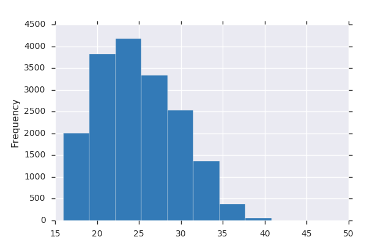

**Common Values**

| Value | Count | Frequency (%) |  |
| --- | --- | --- | --- |
| 25 | 1488 | 8.4% |  |
| 23 | 1366 | 7.7% |  |
| 24 | 1317 | 7.4% |  |
| 22 | 1308 | 7.4% |  |
| 21 | 1276 | 7.2% |  |
| 20 | 1238 | 7.0% |  |
| 26 | 1184 | 6.7% |  |
| 27 | 1126 | 6.4% |  |
| 29 | 1096 | 6.2% |  |
| 19 | 1066 | 6.0% |  |
| Other values (19) | 5216 | 29.5% |  |

**Extreme Values**

Minimum 5 values

| Value | Count | Frequency (%) |  |
| --- | --- | --- | --- |
| 16 | 13 | 0.1% |  |
| 17 | 258 | 1.5% |  |
| 18 | 671 | 3.8% |  |
| 19 | 1066 | 6.0% |  |
| 20 | 1238 | 7.0% |  |

Maximum 5 values

| Value | Count | Frequency (%) |  |
| --- | --- | --- | --- |
| 40 | 7 | 0.0% |  |
| 41 | 3 | 0.0% |  |
| 43 | 2 | 0.0% |  |
| 44 | 2 | 0.0% |  |
| 47 | 1 | 0.0% |  |

Club  
Categorical

| Distinct count | 647 |
| --- | --- |
| Unique (%) | 3.7% |
| Missing (%) | 0.0% |
| Missing (n) | 0 |

| Olympique Lyonnais | 33 |
| --- | --- |
| Chelsea | 33 |
| OGC Nice | 33 |
| Other values (644) | 17582 |

Toggle details

| Value | Count | Frequency (%) |  |
| --- | --- | --- | --- |
| Olympique Lyonnais | 33 | 0.2% |  |
| Chelsea | 33 | 0.2% |  |
| OGC Nice | 33 | 0.2% |  |
| VfL Wolfsburg | 33 | 0.2% |  |
| AS Monaco | 33 | 0.2% |  |
| Everton | 33 | 0.2% |  |
| ES Troyes AC | 33 | 0.2% |  |
| Brighton & Hove Albion | 33 | 0.2% |  |
| Bournemouth | 33 | 0.2% |  |
| Arsenal | 33 | 0.2% |  |
| Other values (637) | 17351 | 98.1% |  |

ID  
Numeric

| Distinct count | 17681 |
| --- | --- |
| Unique (%) | 100.0% |
| Missing (%) | 0.0% |
| Missing (n) | 0 |
| Infinite (%) | 0.0% |
| Infinite (n) | 0 |

| Mean | 207640 |
| --- | --- |
| Minimum | 16 |
| Maximum | 241219 |
| Zeros (%) | 0.0% |

Toggle details

**Statistics**

Quantile statistics

| Minimum | 16 |
| --- | --- |
| 5-th percentile | 156300 |
| Q1 | 192610 |
| Median | 214130 |
| Q3 | 231510 |
| 95-th percentile | 239810 |
| Maximum | 241219 |
| Range | 241203 |
| Interquartile range | 38902 |

Descriptive statistics

| Standard deviation | 32436 |
| --- | --- |
| Coef of variation | 0.15621 |
| Kurtosis | 8.9999 |
| Mean | 207640 |
| MAD | 23388 |
| Skewness | -2.3035 |
| Sum | 3671341698 |
| Variance | 1052100000 |
| Memory size | 916.3 KiB |

**Histogram**

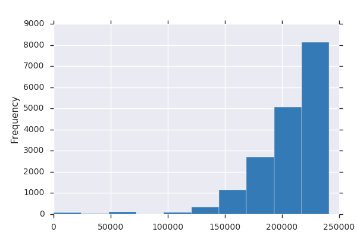

**Common Values**

| Value | Count | Frequency (%) |  |
| --- | --- | --- | --- |
| 231423 | 1 | 0.0% |  |
| 238651 | 1 | 0.0% |  |
| 238225 | 1 | 0.0% |  |
| 211602 | 1 | 0.0% |  |
| 237430 | 1 | 0.0% |  |
| 230037 | 1 | 0.0% |  |
| 223896 | 1 | 0.0% |  |
| 202404 | 1 | 0.0% |  |
| 215708 | 1 | 0.0% |  |
| 234151 | 1 | 0.0% |  |
| Other values (17671) | 17671 | 99.9% |  |

**Extreme Values**

Minimum 5 values

| Value | Count | Frequency (%) |  |
| --- | --- | --- | --- |
| 16 | 1 | 0.0% |  |
| 28 | 1 | 0.0% |  |
| 41 | 1 | 0.0% |  |
| 80 | 1 | 0.0% |  |
| 591 | 1 | 0.0% |  |

Maximum 5 values

| Value | Count | Frequency (%) |  |
| --- | --- | --- | --- |
| 241207 | 1 | 0.0% |  |
| 241213 | 1 | 0.0% |  |
| 241216 | 1 | 0.0% |  |
| 241218 | 1 | 0.0% |  |
| 241219 | 1 | 0.0% |  |

Name  
Categorical

| Distinct count | 16747 |
| --- | --- |
| Unique (%) | 94.7% |
| Missing (%) | 0.0% |
| Missing (n) | 0 |

| J. Williams | 7 |
| --- | --- |
| J. Valencia | 7 |
| J. Rodríguez | 7 |
| Other values (16744) | 17660 |

Toggle details

| Value | Count | Frequency (%) |  |
| --- | --- | --- | --- |
| J. Williams | 7 | 0.0% |  |
| J. Valencia | 7 | 0.0% |  |
| J. Rodríguez | 7 | 0.0% |  |
| Paulinho | 6 | 0.0% |  |
| Wanderson | 6 | 0.0% |  |
| J. Jones | 6 | 0.0% |  |
| Felipe | 6 | 0.0% |  |
| J. Martínez | 5 | 0.0% |  |
| L. Rodríguez | 5 | 0.0% |  |
| L. Martínez | 5 | 0.0% |  |
| Other values (16737) | 17621 | 99.7% |  |

Nationality  
Categorical

| Distinct count | 161 |
| --- | --- |
| Unique (%) | 0.9% |
| Missing (%) | 0.0% |
| Missing (n) | 0 |

| United Kingdom | 2137 |
| --- | --- |
| Germany | 1135 |
| Spain | 1009 |
| Other values (158) | 13400 |

Toggle details

| Value | Count | Frequency (%) |  |
| --- | --- | --- | --- |
| United Kingdom | 2137 | 12.1% |  |
| Germany | 1135 | 6.4% |  |
| Spain | 1009 | 5.7% |  |
| France | 973 | 5.5% |  |
| Argentina | 961 | 5.4% |  |
| Brazil | 806 | 4.6% |  |
| Italy | 797 | 4.5% |  |
| Colombia | 591 | 3.3% |  |
| Japan | 469 | 2.7% |  |
| Netherlands | 429 | 2.4% |  |
| Other values (151) | 8374 | 47.4% |  |

Overall  
Numeric

| Distinct count | 49 |
| --- | --- |
| Unique (%) | 0.3% |
| Missing (%) | 0.0% |
| Missing (n) | 0 |
| Infinite (%) | 0.0% |
| Infinite (n) | 0 |

| Mean | 66.198 |
| --- | --- |
| Minimum | 46 |
| Maximum | 94 |
| Zeros (%) | 0.0% |

Toggle details

**Statistics**

Quantile statistics

| Minimum | 46 |
| --- | --- |
| 5-th percentile | 54 |
| Q1 | 62 |
| Median | 66 |
| Q3 | 71 |
| 95-th percentile | 77 |
| Maximum | 94 |
| Range | 48 |
| Interquartile range | 9 |

Descriptive statistics

| Standard deviation | 6.9826 |
| --- | --- |
| Coef of variation | 0.10548 |
| Kurtosis | 0.0064208 |
| Mean | 66.198 |
| MAD | 5.5283 |
| Skewness | 0.012039 |
| Sum | 1170450 |
| Variance | 48.756 |
| Memory size | 276.3 KiB |

**Histogram**

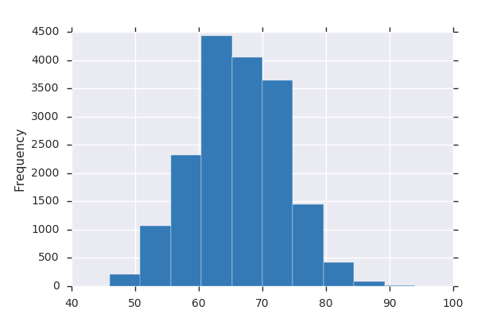

**Common Values**

| Value | Count | Frequency (%) |  |
| --- | --- | --- | --- |
| 66 | 1086 | 6.1% |  |
| 67 | 1056 | 6.0% |  |
| 64 | 1047 | 5.9% |  |
| 68 | 1009 | 5.7% |  |
| 65 | 1002 | 5.7% |  |
| 63 | 903 | 5.1% |  |
| 69 | 892 | 5.0% |  |
| 70 | 885 | 5.0% |  |
| 71 | 824 | 4.7% |  |
| 62 | 812 | 4.6% |  |
| Other values (39) | 8165 | 46.2% |  |

**Extreme Values**

Minimum 5 values

| Value | Count | Frequency (%) |  |
| --- | --- | --- | --- |
| 46 | 8 | 0.0% |  |
| 47 | 16 | 0.1% |  |
| 48 | 23 | 0.1% |  |
| 49 | 49 | 0.3% |  |
| 50 | 115 | 0.7% |  |

Maximum 5 values

| Value | Count | Frequency (%) |  |
| --- | --- | --- | --- |
| 90 | 5 | 0.0% |  |
| 91 | 1 | 0.0% |  |
| 92 | 3 | 0.0% |  |
| 93 | 1 | 0.0% |  |
| 94 | 1 | 0.0% |  |

Potential  
Numeric

| Distinct count | 48 |
| --- | --- |
| Unique (%) | 0.3% |
| Missing (%) | 0.0% |
| Missing (n) | 0 |
| Infinite (%) | 0.0% |
| Infinite (n) | 0 |

| Mean | 71.182 |
| --- | --- |
| Minimum | 46 |
| Maximum | 94 |
| Zeros (%) | 0.0% |

Toggle details

**Statistics**

Quantile statistics

| Minimum | 46 |
| --- | --- |
| 5-th percentile | 62 |
| Q1 | 67 |
| Median | 71 |
| Q3 | 75 |
| 95-th percentile | 82 |
| Maximum | 94 |
| Range | 48 |
| Interquartile range | 8 |

Descriptive statistics

| Standard deviation | 6.0884 |
| --- | --- |
| Coef of variation | 0.085533 |
| Kurtosis | 0.17123 |
| Mean | 71.182 |
| MAD | 4.8165 |
| Skewness | 0.2139 |
| Sum | 1258564 |
| Variance | 37.069 |
| Memory size | 276.3 KiB |

**Histogram**

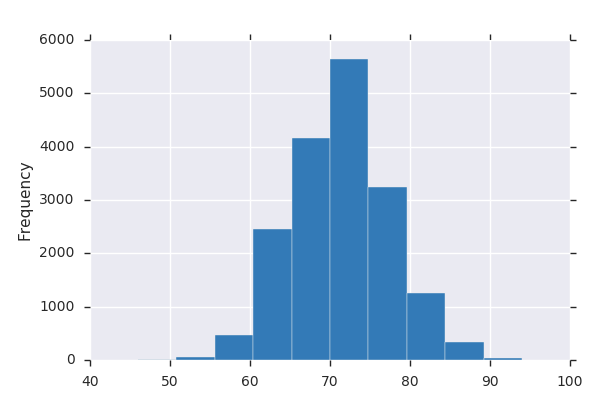

**Common Values**

| Value | Count | Frequency (%) |  |
| --- | --- | --- | --- |
| 70 | 1210 | 6.8% |  |
| 72 | 1196 | 6.8% |  |
| 71 | 1157 | 6.5% |  |
| 69 | 1133 | 6.4% |  |
| 68 | 1083 | 6.1% |  |
| 73 | 1062 | 6.0% |  |
| 67 | 1054 | 6.0% |  |
| 74 | 1010 | 5.7% |  |
| 66 | 897 | 5.1% |  |
| 75 | 874 | 4.9% |  |
| Other values (38) | 7005 | 39.6% |  |

**Extreme Values**

Minimum 5 values

| Value | Count | Frequency (%) |  |
| --- | --- | --- | --- |
| 46 | 2 | 0.0% |  |
| 48 | 1 | 0.0% |  |
| 49 | 2 | 0.0% |  |
| 50 | 1 | 0.0% |  |
| 51 | 2 | 0.0% |  |

Maximum 5 values

| Value | Count | Frequency (%) |  |
| --- | --- | --- | --- |
| 90 | 18 | 0.1% |  |
| 91 | 8 | 0.0% |  |
| 92 | 10 | 0.1% |  |
| 93 | 3 | 0.0% |  |
| 94 | 4 | 0.0% |  |

Preferred Position  
Categorical

| Distinct count | 15 |
| --- | --- |
| Unique (%) | 0.1% |
| Missing (%) | 0.0% |
| Missing (n) | 0 |

| CB | 2652 |
| --- | --- |
| ST | 2255 |
| GK | 1982 |
| Other values (12) | 10792 |

Toggle details

| Value | Count | Frequency (%) |  |
| --- | --- | --- | --- |
| CB | 2652 | 15.0% |  |
| ST | 2255 | 12.8% |  |
| GK | 1982 | 11.2% |  |
| CM | 1949 | 11.0% |  |
| CDM | 1362 | 7.7% |  |
| RM | 1324 | 7.5% |  |
| LM | 1305 | 7.4% |  |
| LB | 1291 | 7.3% |  |
| RB | 1185 | 6.7% |  |
| CAM | 1108 | 6.3% |  |
| Other values (5) | 1268 | 7.2% |  |

Primary Language  
Categorical

| Distinct count | 58 |
| --- | --- |
| Unique (%) | 0.3% |
| Missing (%) | 0.0% |
| Missing (n) | 0 |

| Spanish | 3657 |
| --- | --- |
| English | 3281 |
| German | 1636 |
| Other values (55) | 9107 |

Toggle details

| Value | Count | Frequency (%) |  |
| --- | --- | --- | --- |
| Spanish | 3657 | 20.7% |  |
| English | 3281 | 18.6% |  |
| German | 1636 | 9.3% |  |
| French | 1434 | 8.1% |  |
| Portuguese | 1222 | 6.9% |  |
| Italian | 798 | 4.5% |  |
| Dutch | 713 | 4.0% |  |
| Arabic | 561 | 3.2% |  |
| Japanese | 469 | 2.7% |  |
| Irish | 417 | 2.4% |  |
| Other values (48) | 3493 | 19.8% |  |

Value  
Numeric

| Distinct count | 207 |
| --- | --- |
| Unique (%) | 1.2% |
| Missing (%) | 0.0% |
| Missing (n) | 0 |
| Infinite (%) | 0.0% |
| Infinite (n) | 0 |

| Mean | 2390700 |
| --- | --- |
| Minimum | 0 |
| Maximum | 123000000 |
| Zeros (%) | 0.0% |

Toggle details

**Statistics**

Quantile statistics

| Minimum | 0 |
| --- | --- |
| 5-th percentile | 100000 |
| Q1 | 325000 |
| Median | 700000 |
| Q3 | 2100000 |
| 95-th percentile | 10000000 |
| Maximum | 123000000 |
| Range | 123000000 |
| Interquartile range | 1775000 |

Descriptive statistics

| Standard deviation | 5365700 |
| --- | --- |
| Coef of variation | 2.2444 |
| Kurtosis | 82.173 |
| Mean | 2390700 |
| MAD | 2690000 |
| Skewness | 7.1281 |
| Sum | 42269189950 |
| Variance | 28791000000000 |
| Memory size | 276.3 KiB |

**Histogram**

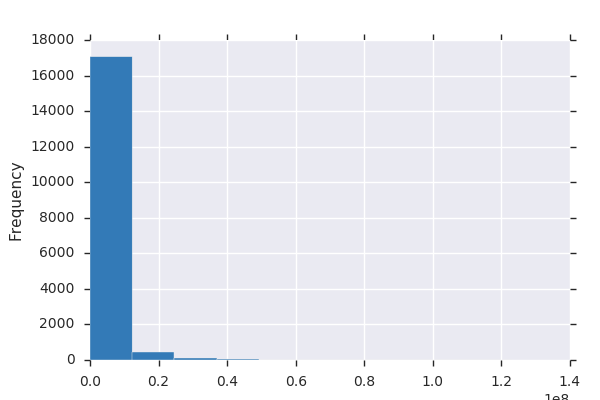

**Common Values**

| Value | Count | Frequency (%) |  |
| --- | --- | --- | --- |
| 1100000 | 387 | 2.2% |  |
| 425000 | 362 | 2.0% |  |
| 350000 | 358 | 2.0% |  |
| 1200000 | 343 | 1.9% |  |
| 375000 | 338 | 1.9% |  |
| 525000 | 328 | 1.9% |  |
| 325000 | 315 | 1.8% |  |
| 400000 | 305 | 1.7% |  |
| 1000000 | 303 | 1.7% |  |
| 475000 | 298 | 1.7% |  |
| Other values (197) | 14344 | 81.1% |  |

**Extreme Values**

Minimum 5 values

| Value | Count | Frequency (%) |  |
| --- | --- | --- | --- |
| 0 | 8 | 0.0% |  |
| 10000 | 13 | 0.1% |  |
| 20000 | 16 | 0.1% |  |
| 30000 | 36 | 0.2% |  |
| 40000 | 67 | 0.4% |  |

Maximum 5 values

| Value | Count | Frequency (%) |  |
| --- | --- | --- | --- |
| 92000000 | 1 | 0.0% |  |
| 95500000 | 1 | 0.0% |  |
| 97000000 | 1 | 0.0% |  |
| 105000000 | 1 | 0.0% |  |
| 123000000 | 1 | 0.0% |  |

Wage  
Numeric

| Distinct count | 141 |
| --- | --- |
| Unique (%) | 0.8% |
| Missing (%) | 0.0% |
| Missing (n) | 0 |
| Infinite (%) | 0.0% |
| Infinite (n) | 0 |

| Mean | 11647 |
| --- | --- |
| Minimum | 1000 |
| Maximum | 565000 |
| Zeros (%) | 0.0% |

Toggle details

**Statistics**

Quantile statistics

| Minimum | 1000 |
| --- | --- |
| 5-th percentile | 1000 |
| Q1 | 2000 |
| Median | 4000 |
| Q3 | 12000 |
| 95-th percentile | 46000 |
| Maximum | 565000 |
| Range | 564000 |
| Interquartile range | 10000 |

Descriptive statistics

| Standard deviation | 23179 |
| --- | --- |
| Coef of variation | 1.99 |
| Kurtosis | 89.569 |
| Mean | 11647 |
| MAD | 12033 |
| Skewness | 7.0537 |
| Sum | 205936000 |
| Variance | 537250000 |
| Memory size | 276.3 KiB |

**Histogram**

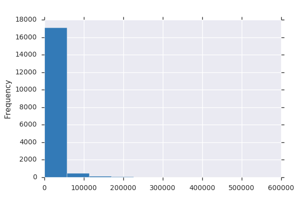

**Common Values**

| Value | Count | Frequency (%) |  |
| --- | --- | --- | --- |
| 1000 | 4199 | 23.7% |  |
| 2000 | 2279 | 12.9% |  |
| 3000 | 1535 | 8.7% |  |
| 4000 | 1196 | 6.8% |  |
| 5000 | 924 | 5.2% |  |
| 6000 | 776 | 4.4% |  |
| 7000 | 612 | 3.5% |  |
| 8000 | 543 | 3.1% |  |
| 9000 | 412 | 2.3% |  |
| 10000 | 380 | 2.1% |  |
| Other values (131) | 4825 | 27.3% |  |

**Extreme Values**

Minimum 5 values

| Value | Count | Frequency (%) |  |
| --- | --- | --- | --- |
| 1000 | 4199 | 23.7% |  |
| 2000 | 2279 | 12.9% |  |
| 3000 | 1535 | 8.7% |  |
| 4000 | 1196 | 6.8% |  |
| 5000 | 924 | 5.2% |  |

Maximum 5 values

| Value | Count | Frequency (%) |  |
| --- | --- | --- | --- |
| 340000 | 2 | 0.0% |  |
| 355000 | 1 | 0.0% |  |
| 370000 | 1 | 0.0% |  |
| 510000 | 1 | 0.0% |  |
| 565000 | 2 | 0.0% |  |

Correlations

Sample

|  | ID | Name | Age | Nationality | Overall | Potential | Club | Value | Wage | Preferred Position | Primary Language |
| --- | --- | --- | --- | --- | --- | --- | --- | --- | --- | --- | --- |
| 0 | 20801 | Cristiano Ronaldo | 32 | Portugal | 94 | 94 | Real Madrid CF | 95500000 | 565000 | ST | Portuguese |
| 1 | 158023 | L. Messi | 30 | Argentina | 93 | 93 | FC Barcelona | 105000000 | 565000 | RW | Spanish |
| 2 | 190871 | Neymar | 25 | Brazil | 92 | 94 | Paris Saint-Germain | 123000000 | 280000 | LW | Portuguese |
| 3 | 176580 | L. Suárez | 30 | Uruguay | 92 | 92 | FC Barcelona | 97000000 | 510000 | ST | Spanish |
| 4 | 167495 | M. Neuer | 31 | Germany | 92 | 92 | FC Bayern Munich | 61000000 | 230000 | GK | German |

```python
pf.ProfileReport(df_player_lang)
```